# milt — Modern Integrated Library for Timeseries

Complete Interactive Documentation

Gideon Nti Boateng

today

# Introduction

**milt** (Modern Integrated Library for Timeseries) is a unified R framework for time series analysis. Think Python’s *Darts* or *sktime*, but natively in R with a tidyverse-friendly API.

## What Can milt Do?

| Capability | Functions |
| --- | --- |
| **Create & manipulate series** | `milt_series()`, `milt_split()`, `milt_window()`, … |
| **TimeSeries operations** | arithmetic (`+`/`-`/`*`/`/`), `milt_stack()`, `milt_step_map()`, `milt_add_datetime_component()`, `milt_add_holidays()` |
| **Forecast** | `milt_model()` → `milt_fit()` → `milt_forecast()` |
| **Filter (smooth observed data)** | `milt_filter()` — moving-average, Kalman, Gaussian Process |
| **Backtest & search hyperparameters** | `milt_backtest()`, `milt_cv()`, `milt_grid_search()` |
| **Calibrated intervals for any model** | `milt_conformal()` |
| **Anomaly detection** | `milt_detector()` → `milt_detect()` |
| **Change-point analysis** | `milt_changepoints()` |
| **Classification** | `milt_classifier()` → `milt_classify_fit()` → `milt_classify_predict()` |
| **Clustering** | `milt_cluster()` |
| **Feature engineering** | `milt_pipeline()` + step DSL (lags, rolling, Fourier, calendar, scale, Box-Cox, diff, map) |
| **Explainability** | `milt_explain()` |
| **Causal impact** | `milt_causal_impact()` |
| **Deployment** | `milt_serve()`, `milt_dashboard()`, `milt_report()`, `milt_save()` |

## Core Design Principles

**Unified pipe-first API.** Every function takes its main object as the first argument so you can chain with `|>`:

```r
milt_model("ets") |> milt_fit(series) |> milt_forecast(horizon = 12)
```

**S3 outside, R6 inside.** You never call `$methods()` directly. Use the exported verbs. The R6 objects live inside and manage state.

**Lazy dependencies.** Heavy packages (`torch`, `xgboost`, `prophet`, …) are only loaded when you use the backend that needs them — you get a friendly error message if the package is missing.

# The MiltSeries — Your Data Container

Everything in milt starts with a `MiltSeries` object. It wraps your data with metadata: a time column, a value column, an optional grouping column, and the series frequency.

## Creating a Series

### From a `ts` object (most common)

```r
# AirPassengers is a built-in R dataset — monthly airline passengers 1949-1960
ap <- milt_series(AirPassengers)
print(ap)
```

```
## # A MiltSeries: 144 x 1 [monthly]
## # Time range : 1949 Jan — 1960 Dec
## # Components : value
## # Gaps       : none
## # A tibble: 6 × 2
##   time       value
##   <date>     <dbl>
## 1 1949-01-01   112
## 2 1949-02-01   118
## 3 1949-03-01   132
## 4 1949-04-01   129
## 5 1949-05-01   121
## 6 1949-06-01   135
## # … with 138 more rows
```

You can also pass the frequency and start explicitly:

```r
ap2 <- milt_series(AirPassengers, frequency = 12, start = c(1949, 1))
print(ap2)
```

```
## # A MiltSeries: 144 x 1 [monthly]
## # Time range : 1949 Jan — 1960 Dec
## # Components : value
## # Gaps       : none
## # A tibble: 6 × 2
##   time       value
##   <date>     <dbl>
## 1 1949-01-01   112
## 2 1949-02-01   118
## 3 1949-03-01   132
## 4 1949-04-01   129
## 5 1949-05-01   121
## 6 1949-06-01   135
## # … with 138 more rows
```

### From a numeric vector

```r
x <- milt_series(
  rnorm(60, mean = 100, sd = 10),
  frequency = 12,
  start     = c(2018, 1)
)
print(x)
```

```
## # A MiltSeries: 60 x 1 [monthly]
## # Time range : 2018 Jan — 2022 Dec
## # Components : value
## # Gaps       : none
## # A tibble: 6 × 2
##   time       value
##   <date>     <dbl>
## 1 2018-01-01  99.3
## 2 2018-02-01  71.8
## 3 2018-03-01 104.
## 4 2018-04-01 102.
## 5 2018-05-01  88.1
## 6 2018-06-01 101.
## # … with 54 more rows
```

### From a data frame / tibble

```r
df <- data.frame(
  date  = seq(as.Date("2020-01-01"), by = "month", length.out = 36),
  sales = cumsum(rnorm(36, 5, 2)) + 100
)

s_df <- milt_series(df, time_col = "date", value_col = "sales", frequency = 12)
print(s_df)
```

```
## # A MiltSeries: 36 x 1 [12]
## # Time range : 2020-01-01 — 2022-12-01
## # Components : sales
## # Gaps       : none
## # A tibble: 6 × 2
##   date       sales
##   <date>     <dbl>
## 1 2020-01-01  105.
## 2 2020-02-01  111.
## 3 2020-03-01  120.
## 4 2020-04-01  124.
## 5 2020-05-01  127.
## 6 2020-06-01  132.
## # … with 30 more rows
```

## Inspecting a Series

```r
ap <- milt_series(AirPassengers)

# Basic metadata
ap$n_timesteps()    # number of observations
```

```
## [1] 144
```

```r
ap$freq()           # "monthly"
```

```
## [1] "monthly"
```

```r
ap$start_time()     # first timestamp
```

```
## [1] "1949-01-01"
```

```r
ap$end_time()       # last timestamp
```

```
## [1] "1960-12-01"
```

```r
ap$values()         # raw numeric vector
```

```
##   [1] 112 118 132 129 121 135 148 148 136 119 104 118 115 126 141 135 125 149
##  [19] 170 170 158 133 114 140 145 150 178 163 172 178 199 199 184 162 146 166
##  [37] 171 180 193 181 183 218 230 242 209 191 172 194 196 196 236 235 229 243
##  [55] 264 272 237 211 180 201 204 188 235 227 234 264 302 293 259 229 203 229
##  [73] 242 233 267 269 270 315 364 347 312 274 237 278 284 277 317 313 318 374
##  [91] 413 405 355 306 271 306 315 301 356 348 355 422 465 467 404 347 305 336
## [109] 340 318 362 348 363 435 491 505 404 359 310 337 360 342 406 396 420 472
## [127] 548 559 463 407 362 405 417 391 419 461 472 535 622 606 508 461 390 432
```

```r
# Convert to a tibble for dplyr workflows
tibble::as_tibble(ap) |> head()
```

```
## # A tibble: 6 × 2
##   time       value
##   <date>     <dbl>
## 1 1949-01-01   112
## 2 1949-02-01   118
## 3 1949-03-01   132
## 4 1949-04-01   129
## 5 1949-05-01   121
## 6 1949-06-01   135
```

## Subsetting and Slicing

```r
# Head / tail
milt_head(ap, 6)
```

```
## # A MiltSeries: 6 x 1 [monthly]
## # Time range : 1949 Jan — 1949 Jun
## # Components : value
## # Gaps       : none
## # A tibble: 6 × 2
##   time       value
##   <date>     <dbl>
## 1 1949-01-01   112
## 2 1949-02-01   118
## 3 1949-03-01   132
## 4 1949-04-01   129
## 5 1949-05-01   121
## 6 1949-06-01   135
```

```r
milt_tail(ap, 6)
```

```
## # A MiltSeries: 6 x 1 [monthly]
## # Time range : 1960 Jul — 1960 Dec
## # Components : value
## # Gaps       : none
## # A tibble: 6 × 2
##   time       value
##   <date>     <dbl>
## 1 1960-07-01   622
## 2 1960-08-01   606
## 3 1960-09-01   508
## 4 1960-10-01   461
## 5 1960-11-01   390
## 6 1960-12-01   432
```

```r
# Extract a date window
milt_window(ap,
  start = as.Date("1955-01-01"),
  end   = as.Date("1957-12-01")
)
```

```
## # A MiltSeries: 36 x 1 [monthly]
## # Time range : 1955 Jan — 1957 Dec
## # Components : value
## # Gaps       : none
## # A tibble: 6 × 2
##   time       value
##   <date>     <dbl>
## 1 1955-01-01   242
## 2 1955-02-01   233
## 3 1955-03-01   267
## 4 1955-04-01   269
## 5 1955-05-01   270
## 6 1955-06-01   315
## # … with 30 more rows
```

```r
# [ operator — same as milt_window() but by position
ap[1:24]
```

```
## # A MiltSeries: 24 x 1 [monthly]
## # Time range : 1949 Jan — 1950 Dec
## # Components : value
## # Gaps       : none
## # A tibble: 6 × 2
##   time       value
##   <date>     <dbl>
## 1 1949-01-01   112
## 2 1949-02-01   118
## 3 1949-03-01   132
## 4 1949-04-01   129
## 5 1949-05-01   121
## 6 1949-06-01   135
## # … with 18 more rows
```

## Train / Test Split

```r
# 80% train, 20% test
spl <- milt_split(ap, ratio = 0.8)
cat("Train:", spl$train$n_timesteps(), "obs\n")
```

```
## Train: 115 obs
```

```r
cat("Test: ", spl$test$n_timesteps(),  "obs\n")
```

```
## Test:  29 obs
```

```r
# Split at a specific date
spl2 <- milt_split_at(ap, time = as.Date("1958-01-01"))
cat("Train ends:", format(spl2$train$end_time()), "\n")
```

```
## Train ends: 1957-12-01
```

```r
cat("Test starts:", format(spl2$test$start_time()), "\n")
```

```
## Test starts: 1958-01-01
```

## Concatenation and Resampling

```r
s1 <- ap[1:60]
s2 <- ap[61:144]
recombined <- milt_concat(s1, s2)
recombined$n_timesteps()
```

```
## [1] 144
```

```r
# Resample to quarterly (from monthly)
ap_q <- milt_resample(ap, period = "quarterly", agg_fn = sum)
print(ap_q)
```

```
## # A MiltSeries: 48 x 1 [quarterly]
## # Time range : 1949 Q1 — 1960 Q4
## # Components : value
## # Gaps       : none
## # A tibble: 6 × 2
##   time       value
##   <date>     <dbl>
## 1 1949-01-01   362
## 2 1949-04-01   385
## 3 1949-07-01   432
## 4 1949-10-01   341
## 5 1950-01-01   382
## 6 1950-04-01   409
## # … with 42 more rows
```

## Handling Missing Values

```r
# Introduce a gap then fill it
vals <- ap$values()
vals[c(10, 11, 12)] <- NA
s_na <- milt_series(vals, frequency = 12, start = c(1949, 1))

# Fill using linear interpolation
s_filled <- milt_fill_gaps(s_na, method = "linear")
```

```
## Series has no gaps; returning unchanged.
```

```r
print(s_filled)
```

```
## # A MiltSeries: 144 x 1 [monthly]
## # Time range : 1949 Jan — 1960 Dec
## # Components : value
## # Gaps       : none
## # A tibble: 6 × 2
##   time       value
##   <date>     <dbl>
## 1 1949-01-01   112
## 2 1949-02-01   118
## 3 1949-03-01   132
## 4 1949-04-01   129
## 5 1949-05-01   121
## 6 1949-06-01   135
## # … with 138 more rows
```

## Visualising a Series

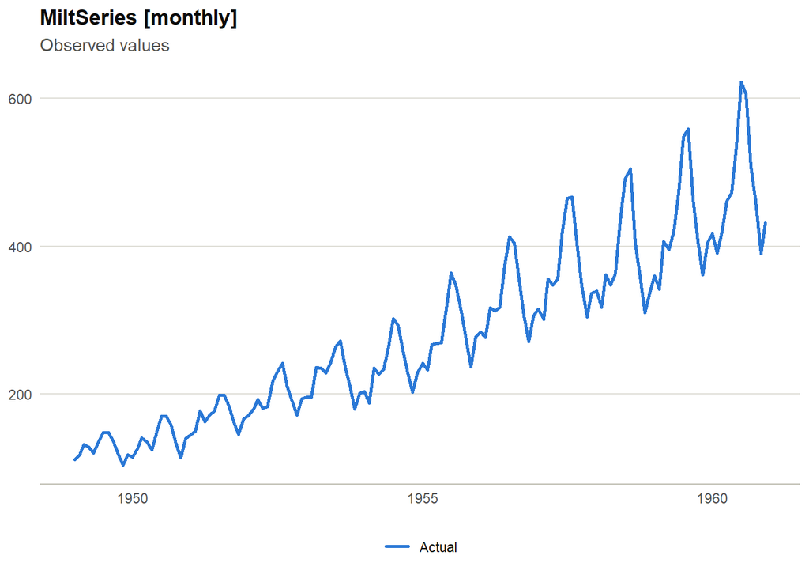

```r
plot(ap)
```

# TimeSeries Operations

Beyond creation and slicing (@sec-series), milt supports the same everyday `TimeSeries` operations Python’s Darts offers: arithmetic, stacking, generic mapping, and enriching a series with new calendar/holiday components.

## Arithmetic Operations

`+`, `-`, `*`, `/`, and `^` work directly on `MiltSeries` objects — against a scalar, or against another `MiltSeries` that shares an identical time index.

```r
ap <- milt_series(AirPassengers)

bumped   <- ap * 1.05          # scale every value up 5%
shifted  <- ap + 10            # scalar addition
identity <- ap - ap            # elementwise difference of two series

print(bumped)
```

```
## # A MiltSeries: 144 x 1 [monthly]
## # Time range : 1949 Jan — 1960 Dec
## # Components : value
## # Gaps       : none
## # A tibble: 6 × 2
##   time       value
##   <date>     <dbl>
## 1 1949-01-01  118.
## 2 1949-02-01  124.
## 3 1949-03-01  139.
## 4 1949-04-01  135.
## 5 1949-05-01  127.
## 6 1949-06-01  142.
## # … with 138 more rows
```

```r
identical(as.numeric((ap - ap)$values()), rep(0, ap$n_timesteps()))
```

```
## [1] TRUE
```

Series must share an identical time index to be combined with each other — mismatched indices raise a `milt_error_incompatible_series` error rather than silently misaligning data.

## Stacking

`milt_stack()` combines two or more series that share the same time index into a single **multivariate** series, placing each input’s components side by side. This is different from `milt_concat()`, which joins series end-to-end along *time* rather than side-by-side along *components*.

```r
smoothed <- milt_filter(ap, "moving_average", window = 12L)
stacked  <- milt_stack(ap, smoothed)

stacked$n_components()   # 2 — "value" and "value_2"
```

```
## [1] 2
```

```r
stacked$is_univariate()  # FALSE
```

```
## [1] FALSE
```

## Mapping — On Values, and On Both Timestamps and Values

`milt_step_map()` applies an arbitrary function elementwise. Supply a one-argument function to transform values only, or a **two-argument** function `function(time, value)` to also use the timestamp — milt detects the arity automatically.

```r
# Values only
log_out <- milt_step_map(ap, fn = log1p, inverse_fn = expm1)
log_out$series
```

```
## # A MiltSeries: 144 x 1 [monthly]
## # Time range : 1949 Jan — 1960 Dec
## # Components : value
## # Gaps       : none
## # A tibble: 6 × 2
##   time       value
##   <date>     <dbl>
## 1 1949-01-01  4.73
## 2 1949-02-01  4.78
## 3 1949-03-01  4.89
## 4 1949-04-01  4.87
## 5 1949-05-01  4.80
## 6 1949-06-01  4.91
## # … with 138 more rows
```

```r
# Both timestamps and values: zero out the first year on record
trimmed_out <- milt_step_map(ap, fn = function(time, value) {
  ifelse(lubridate::year(time) == lubridate::year(min(time)), 0, value)
})
trimmed_out$series
```

```
## # A MiltSeries: 144 x 1 [monthly]
## # Time range : 1949 Jan — 1960 Dec
## # Components : value
## # Gaps       : none
## # A tibble: 6 × 2
##   time       value
##   <date>     <dbl>
## 1 1949-01-01     0
## 2 1949-02-01     0
## 3 1949-03-01     0
## 4 1949-04-01     0
## 5 1949-05-01     0
## 6 1949-06-01     0
## # … with 138 more rows
```

## Adding a Datetime Attribute as an Extra Dimension

`milt_add_datetime_component()` extracts a calendar attribute (month, quarter, day of week, …) from the time index and appends it as a **new component** — turning a univariate series multivariate, ready to use as a model covariate.

```r
with_month <- milt_add_datetime_component(ap, "month")
with_month$as_tibble()
```

```
## # A tibble: 144 × 3
##    time       value month
##    <date>     <dbl> <dbl>
##  1 1949-01-01   112     1
##  2 1949-02-01   118     2
##  3 1949-03-01   132     3
##  4 1949-04-01   129     4
##  5 1949-05-01   121     5
##  6 1949-06-01   135     6
##  7 1949-07-01   148     7
##  8 1949-08-01   148     8
##  9 1949-09-01   136     9
## 10 1949-10-01   119    10
## # ℹ 134 more rows
```

```r
# Cyclic encoding avoids the false "December is far from January" discontinuity
with_month_cyclic <- milt_add_datetime_component(ap, "month", cyclic = TRUE)
with_month_cyclic$n_components()   # 3: value, month_sin, month_cos
```

```
## [1] 3
```

## Adding a Binary Holidays Component

`milt_add_holidays()` appends a `0`/`1` column flagging holiday dates — either from a built-in calendar (currently `"US"` federal holidays) or a custom `dates` vector for any other calendar.

```r
with_holidays <- milt_add_holidays(ap, country = "US")
sum(with_holidays$as_tibble()$is_holiday)   # number of holiday months on record
```

```
## [1] 14
```

```r
# Custom calendar
custom <- milt_add_holidays(ap, dates = as.Date(c("1955-11-24", "1956-11-22")),
                             name = "is_black_friday_month")
```

## Differencing

Covered in full under *Individual Feature Steps* (@sec-steps) — `milt_step_diff()` applies sequential lagged differencing (e.g. `lags = c(1, 12)` removes a trend, then a yearly seasonal pattern) and is invertible via `milt_step_undiff()`.

## Working with Covariates

Beyond the series’ own values, milt supports three kinds of external covariate data via `milt_add_covariates()` — mirroring Darts’ `past_covariates` / `future_covariates` / static-covariates model:

- **`"past"`** — time-varying covariates observed over the same time range as the series (e.g. a promotion flag, competitor pricing). Used for in-sample feature enrichment.
- **`"future"`** — time-varying covariates available *beyond* the series end (e.g. a calendar feature, a known future price). Used by models to produce covariate-informed forecasts.
- **`"static"`** — scalar attributes per group that never change over time (e.g. store size, region). Only meaningful for a multi-series (grouped) `MiltSeries`.

`milt_add_covariates()` attaches the data and returns the (mutated) series; `milt_get_covariates()` retrieves what’s stored.

```r
ap    <- milt_series(AirPassengers)
dates <- ap$as_tibble()$time

# A past covariate: the calendar month as a plain integer
month_cov <- data.frame(time = dates, month_num = as.integer(format(dates, "%m")))
ap2 <- milt_add_covariates(ap, month_cov, type = "past", time_col = "time")
```

```
## Added past covariates to <MiltSeries> (1 covariate column).
```

```r
milt_get_covariates(ap2, type = "past")
```

```
## # A tibble: 144 × 2
##    time       month_num
##    <date>         <int>
##  1 1949-01-01         1
##  2 1949-02-01         2
##  3 1949-03-01         3
##  4 1949-04-01         4
##  5 1949-05-01         5
##  6 1949-06-01         6
##  7 1949-07-01         7
##  8 1949-08-01         8
##  9 1949-09-01         9
## 10 1949-10-01        10
## # ℹ 134 more rows
```

Static covariates require a grouped series — one row per group value:

```r
tbl <- data.frame(
  date  = rep(seq(as.Date("2020-01-01"), by = "month", length.out = 24), 2),
  sales = c(cumsum(rnorm(24, 5)), cumsum(rnorm(24, 8))),
  store = rep(c("A", "B"), each = 24)
)
grouped <- milt_series(tbl, time_col = "date", value_cols = "sales", group_col = "store")

store_attrs <- data.frame(store = c("A", "B"), size_sqft = c(1200, 3400))
grouped2 <- milt_add_covariates(grouped, store_attrs, type = "static", group_col = "store")
```

```
## Added static covariates to <MiltSeries> (1 covariate column).
```

```r
milt_get_covariates(grouped2, type = "static")
```

```
## # A tibble: 2 × 2
##   store size_sqft
##   <chr>     <dbl>
## 1 A          1200
## 2 B          3400
```

Static covariates are automatically sliced per group and passed through when a model trains group-by-group — see `milt_local_model()` and `milt_global_model()` in *Multi-Series Analysis* (@sec-multi-series).

# Exploratory Data Analysis

`milt_eda()` gives you a quick statistical profile of your series — trend direction, seasonality, stationarity, and outlier counts.

```r
ap <- milt_series(AirPassengers)
eda_result <- milt_eda(ap)
```

```
## # MiltEDA
## # Series  : 144 obs  1949-01-01 — 1960-12-01
## # Freq    : monthly
## ## Descriptive Statistics
## # A tibble: 11 × 2
##    stat        value
##    <chr>       <dbl>
##  1 n         144
##  2 mean      280.
##  3 sd        120.
##  4 min       104
##  5 q25       180
##  6 median    266.
##  7 q75       360.
##  8 max       622
##  9 skewness    0.571
## 10 kurtosis    2.57
## 11 n_missing   0
## ## Stationarity
## #  ADF  p-value : 0.01
## #  KPSS p-value : 0.01
## #  Likely stationary: FALSE## Seasonality
## #  Detected period   : 12
## #  Seasonal strength : 0.462
## #  Has seasonality   : TRUE
```

```r
print(eda_result)
```

```
## # MiltEDA
## # Series  : 144 obs  1949-01-01 — 1960-12-01
## # Freq    : monthly
## ## Descriptive Statistics
## # A tibble: 11 × 2
##    stat        value
##    <chr>       <dbl>
##  1 n         144
##  2 mean      280.
##  3 sd        120.
##  4 min       104
##  5 q25       180
##  6 median    266.
##  7 q75       360.
##  8 max       622
##  9 skewness    0.571
## 10 kurtosis    2.57
## 11 n_missing   0
## ## Stationarity
## #  ADF  p-value : 0.01
## #  KPSS p-value : 0.01
## #  Likely stationary: FALSE## Seasonality
## #  Detected period   : 12
## #  Seasonal strength : 0.462
## #  Has seasonality   : TRUE
```

## ACF and Decomposition Plots

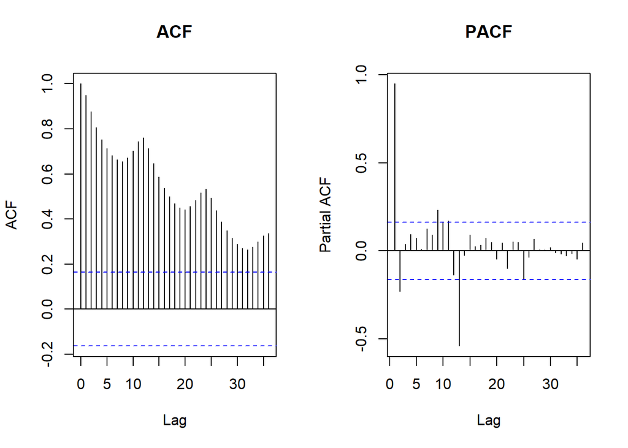

```r
milt_plot_acf(ap, lag.max = 36L)
```

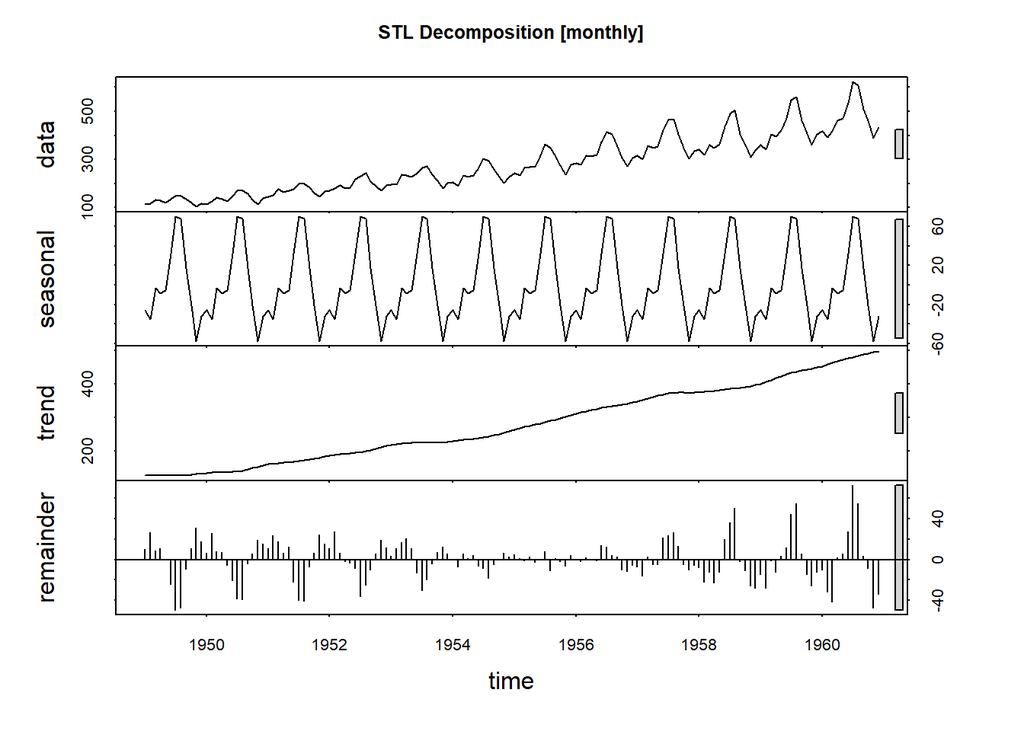

```r
milt_plot_decomp(ap)
```

## Series Diagnostics with Recommendations

`milt_diagnose()` runs a suite of statistical tests and prints model recommendations.

```r
milt_diagnose(ap)
```

```
## # MiltDiagnosis
## # Series    : 144 obs @ monthly# Range     : 1949-01-01 — 1960-12-01
## Stationarity : stationary (CV ratio = 0.028)Seasonality  : seasonal (strength = 0.462, period = 12)Trend        : trend present (slope = 2.6572, p = 0)Gaps         : noneOutliers     : none
## Recommendations:
## • Significant linear trend detected. Models without detrending may underfit.• Seasonality detected (strength = 0.46, period = 12). Use a seasonal model (ETS, SARIMA, STL).
```

## Inspecting Seasonality

`milt_check_seasonality()` searches the ACF for the strongest *significant* local maximum (via Bartlett’s formula for the ACF’s standard error under a white-noise null) and reports it as the detected seasonal period — useful for confirming a `period`/`season` argument before fitting a seasonal model.

```r
milt_check_seasonality(ap, max_lag = 24L)
```

```
## $is_seasonal
## [1] TRUE
##
## $period
## [1] 12
```

```r
# A non-seasonal series correctly reports is_seasonal = FALSE
white_noise <- milt_series(rnorm(120), frequency = "monthly", start = c(2015, 1))
milt_check_seasonality(white_noise, max_lag = 24L)
```

```
## $is_seasonal
## [1] FALSE
##
## $period
## [1] NA
```

# Forecasting

## The Universal Forecasting Interface

milt uses the same three-step pipeline for every model:

```
milt_model("<name>")  →  milt_fit(<series>)  →  milt_forecast(horizon = <h>)
```

Let’s see what models are available:

```r
list_milt_models()
```

```
## # A tibble: 31 × 6
##    name        description    multivariate probabilistic covariates multi_series
##    <chr>       <chr>          <lgl>        <lgl>         <lgl>      <lgl>
##  1 snaive      "Seasonal Nai… FALSE        TRUE          FALSE      FALSE
##  2 knn         "K-Nearest Ne… FALSE        TRUE          FALSE      FALSE
##  3 ets         "Exponential … FALSE        TRUE          FALSE      FALSE
##  4 nbeats      ""             FALSE        FALSE         FALSE      FALSE
##  5 auto_arima  "Automatic AR… FALSE        TRUE          TRUE       FALSE
##  6 svm         "Support Vect… FALSE        TRUE          FALSE      FALSE
##  7 stl         "STL decompos… FALSE        TRUE          FALSE      FALSE
##  8 elastic_net ""             FALSE        FALSE         FALSE      FALSE
##  9 dlinear     ""             FALSE        FALSE         FALSE      FALSE
## 10 deepar      ""             FALSE        FALSE         FALSE      FALSE
## # ℹ 21 more rows
```

## Refitting on New Data

In production, new observations keep arriving and a deployed model needs to keep up. `milt_refit()` retrains a model with the **same hyperparameters** it was originally configured with, just on an updated series — no re-tuning, no need to reconstruct the `milt_model(...)` call from scratch:

```r
initial <- milt_series(AirPassengers[1:120], frequency = 12, start = c(1949, 1))
m       <- milt_model("naive") |> milt_fit(initial)
```

```
## Fitting <MiltNaive> model…
## Done in 0s.
```

```r
# A month later, more data has arrived
updated <- milt_series(AirPassengers[1:132], frequency = 12, start = c(1949, 1))
m       <- milt_refit(m, updated)
```

```
## Fitting <MiltNaive> model…
## Done in 0s.
```

```r
milt_forecast(m, horizon = 12)
```

```
## # A MiltForecast <naive>: horizon = 12# Forecast from: 1959-12-01# Intervals    : 80, 95%#
## # A tibble: 6 × 7
##   time       .model .mean .lower_80 .upper_80 .lower_95 .upper_95
##   <date>     <chr>  <dbl>     <dbl>     <dbl>     <dbl>     <dbl>
## 1 1960-01-01 naive    405      365.      445.      344.      466.
## 2 1960-02-01 naive    405      348.      462.      318.      492.
## 3 1960-03-01 naive    405      335.      475.      299.      511.
## 4 1960-04-01 naive    405      325.      485.      282.      528.
## 5 1960-05-01 naive    405      315.      495.      268.      542.
## 6 1960-06-01 naive    405      307.      503.      255.      555.
## # … with 6 more rows
```

## Classical Statistical Models

### ARIMA

Auto-ARIMA automatically selects the best (p, d, q) order.

```r
ap <- milt_series(AirPassengers)

arima_fit <- milt_model("auto_arima") |> milt_fit(ap)
```

```
## Fitting <MiltAutoArima> model…
## Done in 2.87s.
```

```r
arima_fct <- milt_forecast(arima_fit, horizon = 24)

print(arima_fct)
```

```
## # A MiltForecast <auto_arima>: horizon = 24# Forecast from: 1960-12-01# Intervals    : 80, 95%#
## # A tibble: 6 × 7
##   time       .model     .mean .lower_80 .upper_80 .lower_95 .upper_95
##   <date>     <chr>      <dbl>     <dbl>     <dbl>     <dbl>     <dbl>
## 1 1961-01-01 auto_arima  446.      431.      460.      423.      468.
## 2 1961-02-01 auto_arima  420.      403.      438.      394.      447.
## 3 1961-03-01 auto_arima  449.      430.      469.      419.      479.
## 4 1961-04-01 auto_arima  492.      471.      513.      460.      524.
## 5 1961-05-01 auto_arima  503.      482.      525.      470.      537.
## 6 1961-06-01 auto_arima  567.      544.      589.      532.      601.
## # … with 18 more rows
```

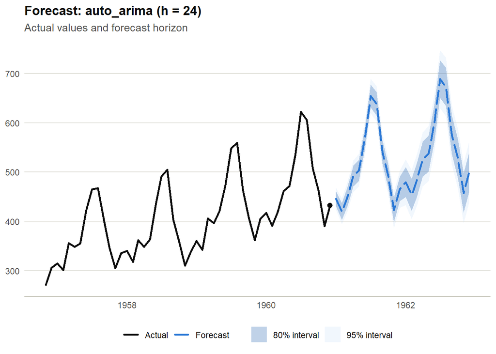

```r
plot(arima_fct)
```

### ETS (Exponential Smoothing)

```r
ets_fct <- milt_model("ets") |>
  milt_fit(ap) |>
  milt_forecast(horizon = 24)
```

```
## Fitting <MiltEts> model…
## Done in 1.63s.
```

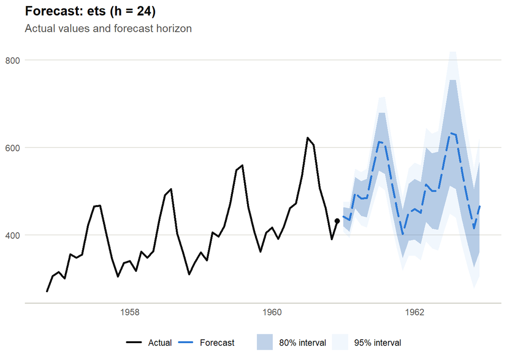

```r
plot(ets_fct)
```

### STL Decomposition

```r
stl_fct <- milt_model("stl") |>
  milt_fit(ap) |>
  milt_forecast(horizon = 24)
```

```
## Fitting <MiltStl> model…
## Done in 0s.
```

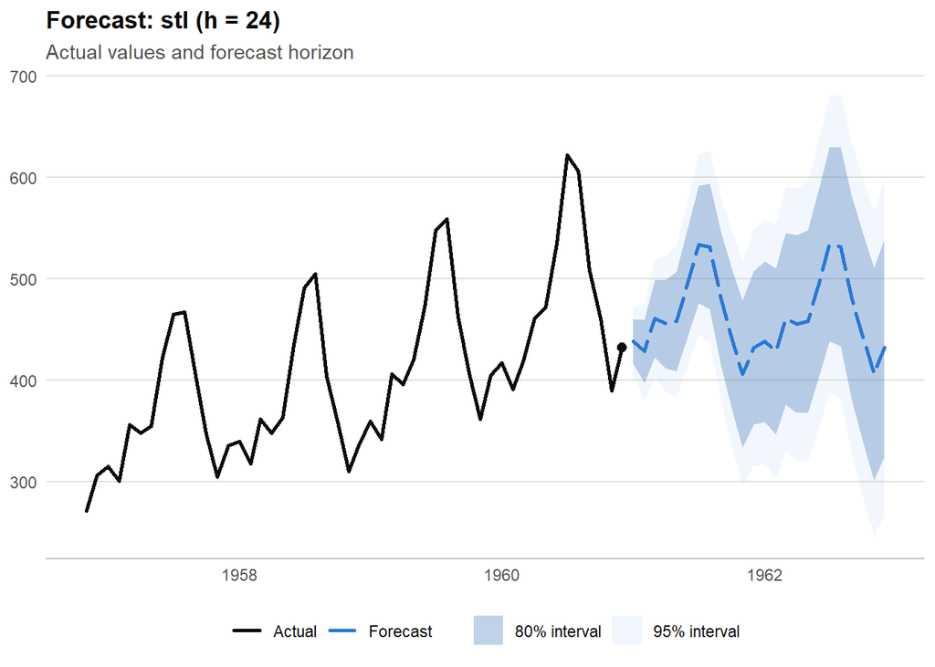

```r
plot(stl_fct)
```

### Theta Method

```r
theta_fct <- milt_model("theta") |>
  milt_fit(ap) |>
  milt_forecast(horizon = 12)
```

```
## Fitting <MiltTheta> model…
## Done in 0s.
```

```r
print(theta_fct)
```

```
## # A MiltForecast <theta>: horizon = 12# Forecast from: 1960-12-01# Intervals    : 80, 95%#
## # A tibble: 6 × 7
##   time       .model .mean .lower_80 .upper_80 .lower_95 .upper_95
##   <date>     <chr>  <dbl>     <dbl>     <dbl>     <dbl>     <dbl>
## 1 1961-01-01 theta   440.      426.      454.      419.      461.
## 2 1961-02-01 theta   428.      410.      446.      401.      456.
## 3 1961-03-01 theta   490.      468.      511.      457.      522.
## 4 1961-04-01 theta   476.      451.      500.      439.      513.
## 5 1961-05-01 theta   480.      453.      507.      439.      521.
## 6 1961-06-01 theta   545.      516.      575.      501.      590.
## # … with 6 more rows
```

### TBATS

Good for complex seasonality (e.g. daily data with weekly + annual cycles).

```r
tbats_fct <- milt_model("tbats") |>
  milt_fit(ap) |>
  milt_forecast(horizon = 12)
```

```
## Fitting <MiltTBATS> model…
## Done in 4.91s.
```

```r
print(tbats_fct)
```

```
## # A MiltForecast <tbats>: horizon = 12# Forecast from: 1960-12-01# Intervals    : 80, 95%#
## # A tibble: 6 × 7
##   time       .model .mean .lower_80 .upper_80 .lower_95 .upper_95
##   <date>     <chr>  <dbl>     <dbl>     <dbl>     <dbl>     <dbl>
## 1 1961-01-01 tbats   451.      430.      473.      420.      485.
## 2 1961-02-01 tbats   440.      414.      467.      401.      482.
## 3 1961-03-01 tbats   509.      475.      547.      457.      567.
## 4 1961-04-01 tbats   496.      458.      537.      439.      560.
## 5 1961-05-01 tbats   498.      456.      544.      436.      570.
## 6 1961-06-01 tbats   567.      516.      624.      491.      656.
## # … with 6 more rows
```

### Prophet (Facebook)

```r
prophet_fct <- milt_model("prophet") |>
  milt_fit(ap) |>
  milt_forecast(horizon = 24)

plot(prophet_fct)
```

### Croston (Intermittent Demand)

Croston’s method is designed for intermittent (sparse) demand series.

```r
# Simulate intermittent demand
demand <- c(0,0,3,0,0,0,2,0,5,0,0,1,0,0,0,4,0,0,2,0,
            0,0,1,0,3,0,0,0,2,0,0,1,0,0,5,0)
demand_series <- milt_series(demand, frequency = 12, start = c(2020, 1))

croston_fct <- milt_model("croston") |>
  milt_fit(demand_series) |>
  milt_forecast(horizon = 12)
```

```
## Fitting <MiltCroston> model…
## Done in 0s.
```

```r
print(croston_fct)
```

```
## # A MiltForecast <croston>: horizon = 12# Forecast from: 2022-12-01#
## # A tibble: 6 × 3
##   time       .model  .mean
##   <date>     <chr>   <dbl>
## 1 2023-01-01 croston 0.882
## 2 2023-02-01 croston 0.882
## 3 2023-03-01 croston 0.882
## 4 2023-04-01 croston 0.882
## 5 2023-05-01 croston 0.882
## 6 2023-06-01 croston 0.882
## # … with 6 more rows
```

### Naive Baseline

Repeats the last observed value for every step of the forecast horizon — equivalent to a random-walk forecast. Always a good baseline to beat; no model deserves trust until it clears this bar.

```r
naive_fct <- milt_model("naive") |>
  milt_fit(ap) |>
  milt_forecast(horizon = 12)
```

```
## Fitting <MiltNaive> model…
## Done in 0s.
```

```r
print(naive_fct)
```

```
## # A MiltForecast <naive>: horizon = 12# Forecast from: 1960-12-01# Intervals    : 80, 95%#
## # A tibble: 6 × 7
##   time       .model .mean .lower_80 .upper_80 .lower_95 .upper_95
##   <date>     <chr>  <dbl>     <dbl>     <dbl>     <dbl>     <dbl>
## 1 1961-01-01 naive    432      389.      475.      366.      498.
## 2 1961-02-01 naive    432      371.      493.      339.      525.
## 3 1961-03-01 naive    432      357.      507.      318.      546.
## 4 1961-04-01 naive    432      346.      518.      300.      564.
## 5 1961-05-01 naive    432      335.      529.      284.      580.
## 6 1961-06-01 naive    432      326.      538.      270.      594.
## # … with 6 more rows
```

### Seasonal Naive

Repeats the value from exactly one seasonal cycle ago (for monthly data, the same month from the previous year). A much stronger baseline than plain naive whenever the series has clear seasonality.

```r
snaive_fct <- milt_model("snaive") |>
  milt_fit(ap) |>
  milt_forecast(horizon = 12)
```

```
## Fitting <MiltSNaive> model…
## Done in 0s.
```

```r
print(snaive_fct)
```

```
## # A MiltForecast <snaive>: horizon = 12# Forecast from: 1960-12-01# Intervals    : 80, 95%#
## # A tibble: 6 × 7
##   time       .model .mean .lower_80 .upper_80 .lower_95 .upper_95
##   <date>     <chr>  <dbl>     <dbl>     <dbl>     <dbl>     <dbl>
## 1 1961-01-01 snaive   417      370.      464.      346.      488.
## 2 1961-02-01 snaive   391      344.      438.      320.      462.
## 3 1961-03-01 snaive   419      372.      466.      348.      490.
## 4 1961-04-01 snaive   461      414.      508.      390.      532.
## 5 1961-05-01 snaive   472      425.      519.      401.      543.
## 6 1961-06-01 snaive   535      488.      582.      464.      606.
## # … with 6 more rows
```

### Drift

Extrapolates a straight line through the first and last training observations — captures a linear trend with no seasonality.

```r
drift_fct <- milt_model("drift") |>
  milt_fit(ap) |>
  milt_forecast(horizon = 12)
```

```
## Fitting <MiltDrift> model…
## Done in 0s.
```

```r
print(drift_fct)
```

```
## # A MiltForecast <drift>: horizon = 12# Forecast from: 1960-12-01# Intervals    : 80, 95%#
## # A tibble: 6 × 7
##   time       .model .mean .lower_80 .upper_80 .lower_95 .upper_95
##   <date>     <chr>  <dbl>     <dbl>     <dbl>     <dbl>     <dbl>
## 1 1961-01-01 drift   434.      370.      499.      336.      533.
## 2 1961-02-01 drift   436.      345.      528.      297.      576.
## 3 1961-03-01 drift   439.      327.      551.      267.      610.
## 4 1961-04-01 drift   441.      311.      571.      242.      640.
## 5 1961-05-01 drift   443.      297.      589.      220.      666.
## 6 1961-06-01 drift   445.      285.      606.      200.      690.
## # … with 6 more rows
```

### Mean

Repeats the training-series mean for every forecast step, with a *constant* (non-widening) prediction interval — appropriate only when the series has no trend or seasonality and residuals are i.i.d.

```r
mean_fct <- milt_model("mean") |>
  milt_fit(ap) |>
  milt_forecast(horizon = 12)
```

```
## Fitting <MiltMean> model…
## Done in 0s.
```

```r
print(mean_fct)
```

```
## # A MiltForecast <mean>: horizon = 12# Forecast from: 1960-12-01# Intervals    : 80, 95%#
## # A tibble: 6 × 7
##   time       .model .mean .lower_80 .upper_80 .lower_95 .upper_95
##   <date>     <chr>  <dbl>     <dbl>     <dbl>     <dbl>     <dbl>
## 1 1961-01-01 mean    280.      127.      434.      46.0      515.
## 2 1961-02-01 mean    280.      127.      434.      46.0      515.
## 3 1961-03-01 mean    280.      127.      434.      46.0      515.
## 4 1961-04-01 mean    280.      127.      434.      46.0      515.
## 5 1961-05-01 mean    280.      127.      434.      46.0      515.
## 6 1961-06-01 mean    280.      127.      434.      46.0      515.
## # … with 6 more rows
```

### Moving Average

Forecasts each step as the mean of the last `window` observations, then slides that window forward autoregressively using its *own* forecasts — so far-ahead steps are means of prior forecasts, not just raw data.

```r
ma_fct <- milt_model("moving_average", window = 5L) |>
  milt_fit(ap) |>
  milt_forecast(horizon = 12)
```

```
## Fitting <MiltMovingAverage> model…
## Done in 0s.
```

```r
print(ma_fct)
```

```
## # A MiltForecast <moving_average>: horizon = 12# Forecast from: 1960-12-01# Intervals    : 80, 95%#
## # A tibble: 6 × 7
##   time       .model         .mean .lower_80 .upper_80 .lower_95 .upper_95
##   <date>     <chr>          <dbl>     <dbl>     <dbl>     <dbl>     <dbl>
## 1 1961-01-01 moving_average  479.      409.      550.      372.      587.
## 2 1961-02-01 moving_average  454.      355.      554.      302.      606.
## 3 1961-03-01 moving_average  443.      321.      565.      257.      630.
## 4 1961-04-01 moving_average  440.      299.      580.      225.      655.
## 5 1961-05-01 moving_average  450.      292.      607.      209.      690.
## 6 1961-06-01 moving_average  453.      281.      626.      190.      717.
## # … with 6 more rows
```

## Machine Learning Models

ML models automatically build lag features from the series to train a regression model. You can tune how many lags to use.

### XGBoost

```r
xgb_fct <- milt_model("xgboost", lags = 1:24) |>
  milt_fit(ap) |>
  milt_forecast(horizon = 12)

plot(xgb_fct)
```

### LightGBM

```r
lgb_fct <- milt_model("lightgbm", lags = 1:24) |>
  milt_fit(ap) |>
  milt_forecast(horizon = 12)

print(lgb_fct)
```

### Random Forest

```r
rf_fct <- milt_model("random_forest", lags = 1:12) |>
  milt_fit(ap) |>
  milt_forecast(horizon = 12)

plot(rf_fct)
```

### Elastic Net

```r
en_fct <- milt_model("elastic_net", lags = 1:12) |>
  milt_fit(ap) |>
  milt_forecast(horizon = 12)

print(en_fct)
```

### Support Vector Machine

```r
svm_fct <- milt_model("svm", lags = 1:12) |>
  milt_fit(ap) |>
  milt_forecast(horizon = 12)

print(svm_fct)
```

### K-Nearest Neighbours

```r
knn_fct <- milt_model("knn", lags = 1:12) |>
  milt_fit(ap) |>
  milt_forecast(horizon = 12)
```

```
## Fitting <MiltKNN> model…
## Done in 0s.
```

```r
print(knn_fct)
```

```
## # A MiltForecast <knn>: horizon = 12# Forecast from: 1960-12-01# Intervals    : 80, 95%#
## # A tibble: 6 × 7
##   time       .model .mean .lower_80 .upper_80 .lower_95 .upper_95
##   <date>     <chr>  <dbl>     <dbl>     <dbl>     <dbl>     <dbl>
## 1 1961-01-01 knn     401.      379.      424.      367.      436.
## 2 1961-02-01 knn     409.      387.      432.      375.      444.
## 3 1961-03-01 knn     414.      391.      436.      379.      448.
## 4 1961-04-01 knn     419.      396.      441.      384.      453.
## 5 1961-05-01 knn     437.      414.      459.      402.      471.
## 6 1961-06-01 knn     465.      442.      487.      430.      499.
## # … with 6 more rows
```

## Deep Learning Models (torch)

Deep learning models require the `torch` package with its Lantern C++ backend installed.

```r
# One-time setup — downloads the C++ runtime
install.packages("torch")
torch::install_torch()
```

More generally, `milt_install_backends()` installs (or upgrades) any set of milt’s optional backend packages in one call — `torch` included — so you don’t have to hunt down each Suggests dependency by hand:

```r
milt_install_backends("torch")           # just the DL backend
milt_install_backends(c("xgboost", "prophet"))
milt_install_backends("all")             # every optional backend milt knows about
```

All DL backends follow the same pattern:

```r
#| eval: false
# N-BEATS
nbeats_fct <- milt_model("nbeats", input_chunk_length = 24L, output_chunk_length = 12L) |>
  milt_fit(ap) |>
  milt_forecast(horizon = 12)

# N-HiTS
nhits_fct <- milt_model("nhits", input_chunk_length = 24L, output_chunk_length = 12L) |>
  milt_fit(ap) |>
  milt_forecast(horizon = 12)

# Temporal Convolutional Network (TCN)
tcn_fct <- milt_model("tcn", input_chunk_length = 24L, output_chunk_length = 12L) |>
  milt_fit(ap) |>
  milt_forecast(horizon = 12)

# Temporal Fusion Transformer (TFT)
tft_fct <- milt_model("tft", input_chunk_length = 24L, output_chunk_length = 12L) |>
  milt_fit(ap) |>
  milt_forecast(horizon = 12)

# PatchTST
patch_fct <- milt_model("patch_tst", input_chunk_length = 24L, output_chunk_length = 12L) |>
  milt_fit(ap) |>
  milt_forecast(horizon = 12)

# DeepAR (LSTM + Gaussian likelihood — probabilistic by default)
deepar_fct <- milt_model("deepar", input_chunk_length = 24L, output_chunk_length = 12L) |>
  milt_fit(ap) |>
  milt_forecast(horizon = 12, num_samples = 100L)

# NLinear (Zeng et al. 2022) — subtracts the last observed value before a
# single linear layer, then adds it back; a deceptively strong, cheap
# baseline that often matches much larger Transformer models
nlinear_fct <- milt_model("nlinear", input_chunk_length = 24L, output_chunk_length = 12L) |>
  milt_fit(ap) |>
  milt_forecast(horizon = 12)

# DLinear (Zeng et al. 2022) — decomposes the input window into a
# moving-average trend and a seasonal/residual component, maps each through
# its own linear layer, and sums the two projections
dlinear_fct <- milt_model("dlinear", input_chunk_length = 24L, output_chunk_length = 12L,
                          kernel_size = 25L) |>
  milt_fit(ap) |>
  milt_forecast(horizon = 12)

# TiDE (Das et al. 2023) — an MLP encoder-decoder built from residual
# blocks (Linear -> ReLU -> Linear -> Dropout + skip connection); a cheap,
# strong alternative to attention-based long-horizon models
tide_fct <- milt_model("tide", input_chunk_length = 24L, output_chunk_length = 12L,
                       hidden_size = 64L, n_encoder_layers = 2L, n_decoder_layers = 2L) |>
  milt_fit(ap) |>
  milt_forecast(horizon = 12)

# TSMixer (Chen et al. 2023) — a stack of residual "time-mixing" MLP
# blocks over the lookback window, followed by a linear projection head
# (simplified to time-mixing only, since feature-mixing is degenerate for
# milt's single-channel series)
tsmixer_fct <- milt_model("tsmixer", input_chunk_length = 24L, output_chunk_length = 12L,
                          hidden_size = 64L, n_blocks = 2L) |>
  milt_fit(ap) |>
  milt_forecast(horizon = 12)
```

### Checking the torch device

```r
milt_torch_device()  # returns cuda if GPU available, else cpu
```

## Darts Bridge Backends (Python, via `reticulate`)

For models not yet natively ported to torch-for-R, milt can transparently delegate to Python’s [Darts](https://github.com/unit8co/darts) library through `reticulate`. Call `milt_setup_darts()` once per session to verify (and optionally install) the Python environment.

```r
milt_setup_darts()                      # check only
milt_setup_darts(install = TRUE)        # check + install darts via pip

rnn_fct <- milt_model("darts_rnn", input_chunk_length = 24L, output_chunk_length = 12L) |>
  milt_fit(ap) |>
  milt_forecast(horizon = 12)

transformer_fct <- milt_model("darts_transformer") |>
  milt_fit(ap) |>
  milt_forecast(horizon = 12)

darts_nbeats_fct <- milt_model("darts_nbeats") |>
  milt_fit(ap) |>
  milt_forecast(horizon = 12)
```

# Filtering Models

Filtering is a different job from forecasting: it estimates the underlying signal from noisy observations at the **same** timestamps as the input — it does not extrapolate into the future. Use `milt_filter()` when you want to denoise an already-observed series, e.g. before plotting, before feature engineering, or before feeding a cleaner signal into a downstream model.

All three filters below are implemented on base R (`stats`) — no additional package dependencies.

## Moving Average Filter

A simple rolling-mean smoother.

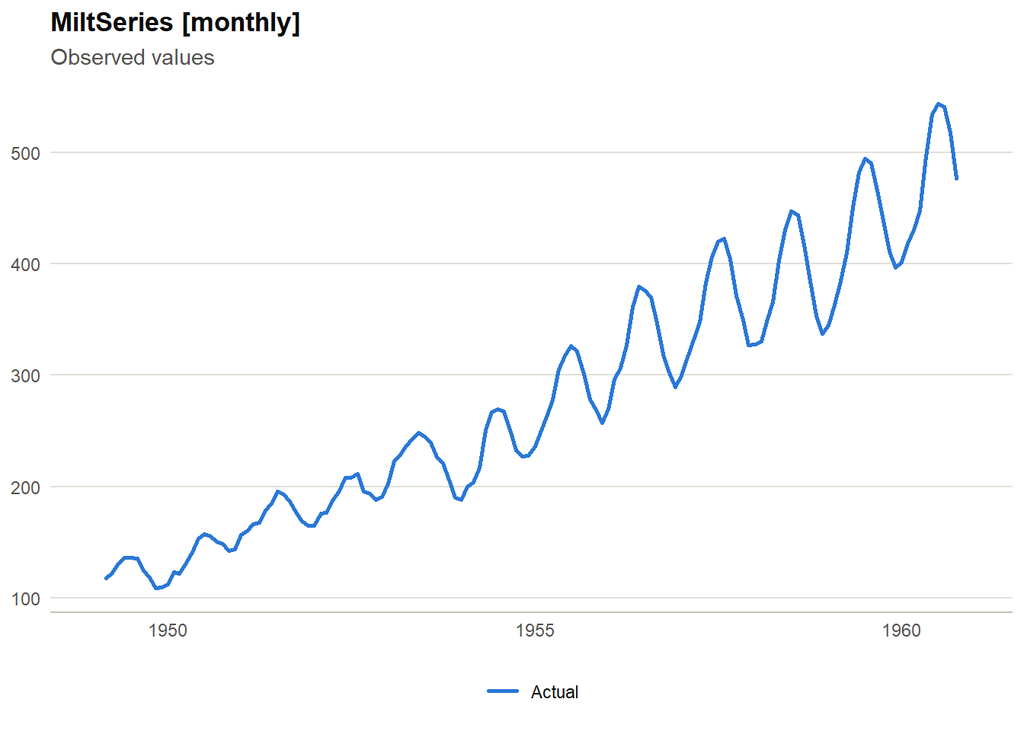

```r
noisy <- milt_series(as.numeric(AirPassengers) + rnorm(144, sd = 15),
                      frequency = "monthly", start = c(1949, 1))

smoothed_ma <- milt_filter(noisy, "moving_average", window = 5L)
plot(smoothed_ma)
```

## Kalman Filter

State-space smoothing via `stats::StructTS()` — models the series as a noisy observation of a hidden local-level (or local-trend / BSM) process and returns the Kalman-smoothed estimate of that hidden state.

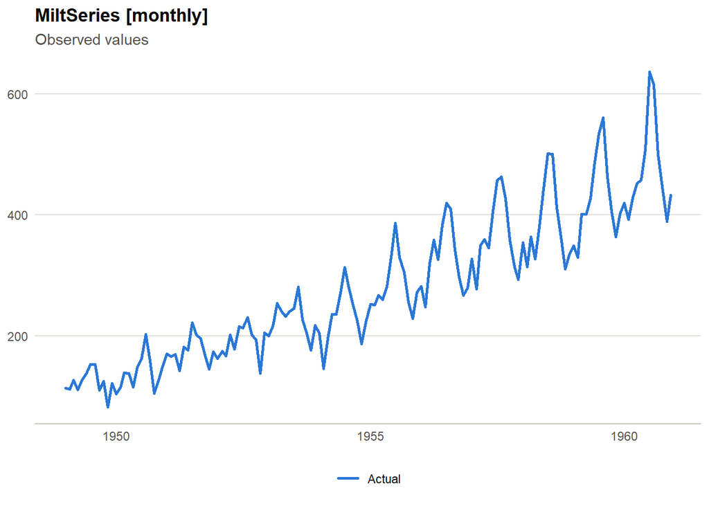

```r
smoothed_kalman <- milt_filter(noisy, "kalman", type = "level")
plot(smoothed_kalman)
```

## Gaussian Process Filter

Fits a Gaussian Process with a squared-exponential (RBF) kernel to the observed points and returns the posterior mean at those same timestamps — a flexible non-parametric smoother.

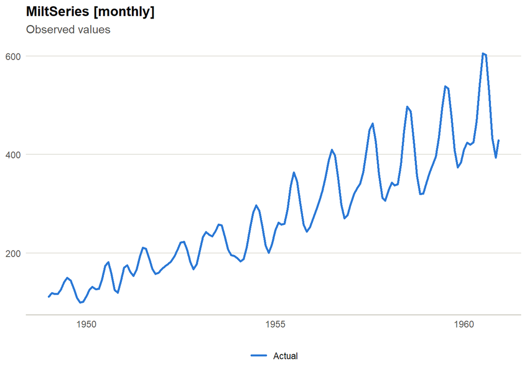

```r
smoothed_gp <- milt_filter(noisy, "gp", length_scale = 3, noise = 5)
plot(smoothed_gp)
```

# Working with Forecasts

A `MiltForecast` object stores the full forecast result — point estimates, prediction intervals, and (for probabilistic models) sample paths.

```r
ap <- milt_series(AirPassengers)
fct <- milt_model("ets") |> milt_fit(ap) |> milt_forecast(horizon = 24)
```

```
## Fitting <MiltEts> model…
## Done in 1.49s.
```

```r
# Inspect
print(fct)
```

```
## # A MiltForecast <ets>: horizon = 24# Forecast from: 1960-12-01# Intervals    : 80, 95%#
## # A tibble: 6 × 7
##   time       .model .mean .lower_80 .upper_80 .lower_95 .upper_95
##   <date>     <chr>  <dbl>     <dbl>     <dbl>     <dbl>     <dbl>
## 1 1961-01-01 ets     442.      420.      464.      408.      476.
## 2 1961-02-01 ets     434.      407.      461.      393.      475.
## 3 1961-03-01 ets     497.      461.      533.      442.      552.
## 4 1961-04-01 ets     483.      444.      523.      423.      544.
## 5 1961-05-01 ets     484.      440.      528.      417.      551.
## 6 1961-06-01 ets     551.      496.      606.      467.      635.
## # … with 18 more rows
```

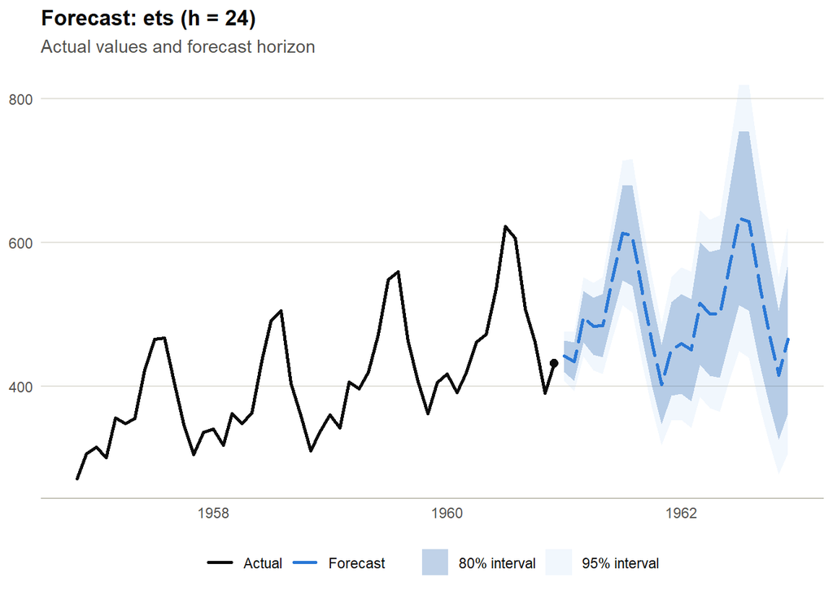

```r
plot(fct)
```

```r
# Extract as a tibble for further processing
tibble::as_tibble(fct) |> head()
```

```
## # A tibble: 6 × 7
##   time       .model .mean .lower_80 .upper_80 .lower_95 .upper_95
##   <date>     <chr>  <dbl>     <dbl>     <dbl>     <dbl>     <dbl>
## 1 1961-01-01 ets     442.      420.      464.      408.      476.
## 2 1961-02-01 ets     434.      407.      461.      393.      475.
## 3 1961-03-01 ets     497.      461.      533.      442.      552.
## 4 1961-04-01 ets     483.      444.      523.      423.      544.
## 5 1961-05-01 ets     484.      440.      528.      417.      551.
## 6 1961-06-01 ets     551.      496.      606.      467.      635.
```

## In-sample Predictions and Residuals

```r
m <- milt_model("ets") |> milt_fit(ap)
```

```
## Fitting <MiltEts> model…
## Done in 1.3s.
```

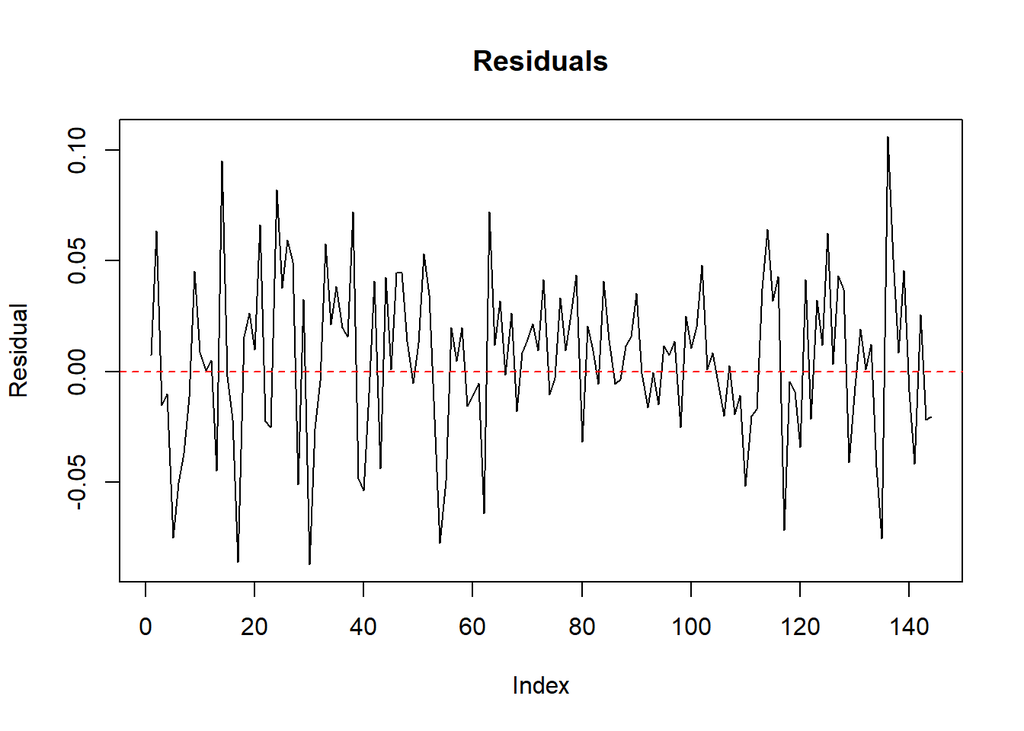

```r
fitted_vals <- milt_predict(m)
residuals   <- milt_residuals(m)

plot(residuals, type = "l", main = "Residuals", ylab = "Residual")
abline(h = 0, col = "red", lty = 2)
```

# Accuracy Metrics

milt ships a comprehensive suite of forecast accuracy functions.

```r
ap   <- milt_series(AirPassengers)
spl  <- milt_split(ap, ratio = 0.8)
fct  <- milt_model("ets") |> milt_fit(spl$train) |> milt_forecast(spl$test$n_timesteps())
```

```
## Fitting <MiltEts> model…
## Done in 1.52s.
```

```r
actual <- spl$test$values()
pred   <- tibble::as_tibble(fct)$.mean
```

```r
# Comprehensive accuracy report
milt_accuracy(actual, pred)
```

```
## # A tibble: 9 × 2
##   metric     value
##   <chr>      <dbl>
## 1 MAE      30.0
## 2 MSE    1282.
## 3 RMSE     35.8
## 4 MAPE      0.0653
## 5 R2        0.790
## 6 WMAPE     0.0681
## 7 OPE       0.0361
## 8 CV        0.0813
## 9 MARRE     0.0961
```

```r
# Individual metrics
cat("MAE:  ", milt_mae(actual, pred), "\n")
```

```
## MAE:   29.97643
```

```r
cat("RMSE: ", milt_rmse(actual, pred), "\n")
```

```
## RMSE:  35.80722
```

```r
cat("MAPE: ", milt_mape(actual, pred), "%\n")
```

```
## MAPE:  0.06533672 %
```

```r
cat("sMAPE:", milt_smape(actual, pred), "%\n")
```

```
## sMAPE: 0.06682579 %
```

```r
cat("MASE: ", milt_mase(actual, pred, spl$train$values()), "\n")
```

```
## MASE:  1.423287
```

```r
cat("R²:   ", milt_r_squared(actual, pred), "\n")
```

```
## R²:    0.789965
```

### Additional Scale-Free Metrics

Useful when comparing accuracy across series with very different scales, or when `milt_mape()` would blow up on near-zero actuals.

```r
cat("wMAPE (robust to near-zero actuals):", milt_wmape(actual, pred), "\n")
```

```
## wMAPE (robust to near-zero actuals): 0.06808022
```

```r
cat("OPE (error of the totals, not per-point):", milt_ope(actual, pred), "\n")
```

```
## OPE (error of the totals, not per-point): 0.03612693
```

```r
cat("Coefficient of Variation (RMSE / mean):", milt_coefficient_of_variation(actual, pred), "\n")
```

```
## Coefficient of Variation (RMSE / mean): 0.08132268
```

```r
cat("MARRE (MAE / range of actual):", milt_marre(actual, pred), "\n")
```

```
## MARRE (MAE / range of actual): 0.09607829
```

```r
cat("RMSLE (penalises relative, not absolute, error):", milt_rmsle(actual, pred), "\n")
```

```
## RMSLE (penalises relative, not absolute, error): 0.07543563
```

`milt_accuracy()` includes `wMAPE`, `OPE`, `CV`, and `MARRE` by default; `RMSLE` is opt-in only (via `metrics = "RMSLE"`) since it errors on values at or below -1:

```r
milt_accuracy(actual, pred, metrics = "RMSLE")
```

```
## # A tibble: 1 × 2
##   metric  value
##   <chr>   <dbl>
## 1 RMSLE  0.0754
```

## Probabilistic Metrics

```r
# For probabilistic forecasts — need sample paths
# (Using simulated samples here for illustration)
samples <- matrix(rnorm(length(actual) * 200, mean = pred, sd = 15),
                  nrow = length(actual), ncol = 200)

cat("CRPS:    ", milt_crps(actual, samples), "\n")
```

```
## CRPS:     23.02569
```

```r
cat("Coverage:", milt_coverage(actual, pred - 1.96*15, pred + 1.96*15), "\n")
```

```
## Coverage: 0.5862069
```

# Backtesting and Model Evaluation

## Simple Backtest

```r
ap <- milt_series(AirPassengers)

bt <- milt_backtest(
  milt_model("ets"),
  series         = ap,
  initial_window = 84,
  horizon        = 12,
  stride         = 12L
)
```

```
## Running expanding backtest (5 folds): ets, h=12
```

```r
print(bt)
```

```
##
## ── MiltBacktest <ets> ──
##
## • Method : expanding
## • Horizon : 12
## • Folds : 5
```

```
##
## ── Summary (across folds)
```

```
## # A tibble: 3 × 5
##   metric    mean      sd     min     max
##   <chr>    <dbl>   <dbl>   <dbl>   <dbl>
## 1 MAE    23.4    11.7    13.8    43.5
## 2 RMSE   28.1    13.3    16.8    50.8
## 3 MAPE    0.0556  0.0233  0.0396  0.0967
```

```r
tibble::as_tibble(bt) |> head()
```

```
## # A tibble: 5 × 6
##   .fold .train_n .test_n  .MAE .RMSE  .MAPE
##   <int>    <int>   <int> <dbl> <dbl>  <dbl>
## 1     1       84      12  13.8  16.8 0.0396
## 2     2       96      12  19.7  24.4 0.0500
## 3     3      108      12  17.3  21.3 0.0450
## 4     4      120      12  43.5  50.8 0.0967
## 5     5      132      12  22.8  27.4 0.0466
```

## Cross-Validation

```r
cv_result <- milt_cv(
  milt_model("auto_arima"),
  series         = ap,
  initial_window = 72,
  horizon        = 12
)
```

```
## Running expanding backtest (5 folds): auto_arima, h=12
```

```r
print(cv_result)
```

```
##
## ── MiltBacktest <auto_arima> ──
##
## • Method : expanding
## • Horizon : 12
## • Folds : 5
```

```
##
## ── Summary (across folds)
```

```
## # A tibble: 3 × 5
##   metric    mean     sd     min     max
##   <chr>    <dbl>  <dbl>   <dbl>   <dbl>
## 1 MAE    20.3    7.00   10.7    29.0
## 2 RMSE   24.6    8.19   12.7    34.6
## 3 MAPE    0.0543 0.0160  0.0329  0.0696
```

## Comparing Multiple Models

```r
cmp <- milt_compare(
  models = list(
    arima = milt_model("auto_arima"),
    ets   = milt_model("ets"),
    naive = milt_model("naive")
  ),
  series  = ap,
  horizon = 12
)
```

```
## Comparing 3 models: arima, ets, naive
## Running backtest for "arima"...
## Running expanding backtest (61 folds): auto_arima, h=12
## Running backtest for "ets"...
## Running expanding backtest (61 folds): ets, h=12
## Running backtest for "naive"...
## Running expanding backtest (61 folds): naive, h=12
```

```r
print(cmp)
```

```
##
## ── MiltComparison - 3 models ──
##
## • Rank metric : MAE
## • Models : arima, ets, naive
```

```
##
## ── Ranked by MAE (mean across folds)
```

```
## # A tibble: 3 × 5
##   model   MAE  RMSE   MAPE  rank
##   <chr> <dbl> <dbl>  <dbl> <int>
## 1 arima  18.3  21.2 0.0491     1
## 2 ets    22.2  26.4 0.0573     2
## 3 naive  63.8  78.6 0.163      3
```

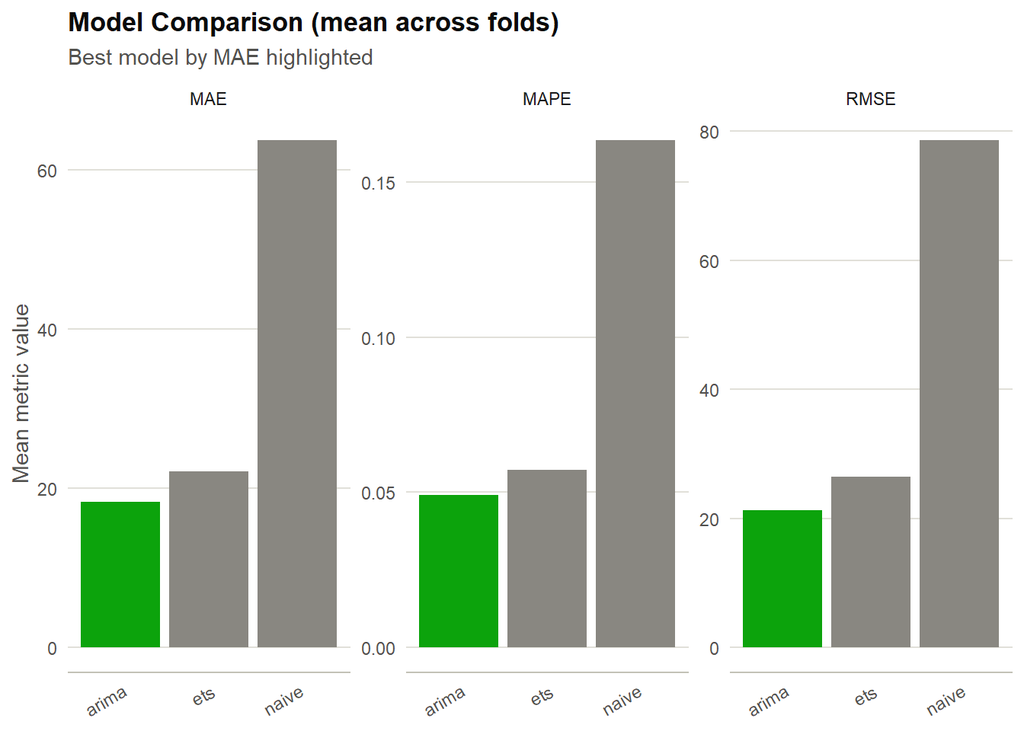

```r
plot(cmp)
```

`cmp` is a `MiltComparison` object (backed by the `MiltComparisonR6` class internally) — like every milt result object it has its own `print()`, `plot()`, and `as_tibble()` methods, so `tibble::as_tibble(cmp)` gets you the ranked comparison table for further `dplyr` work.

## Searching for Hyperparameters via Backtesting

`milt_grid_search()` backtests every combination of a parameter grid and ranks them by a chosen metric — works with *any* registered model, not just one specific method. (Darts’ own quickstart famously demonstrates this with the Theta method’s numeric `theta` parameter; R’s classical `forecast::thetaf()` wrapper has no equivalent tunable parameter, so the example below sweeps `moving_average`’s `window` instead — the workflow generalises to any model with a tunable argument, e.g. `xgboost`’s `nrounds`/`max_depth`, or `ets`’s `damped`.)

```r
milt_grid_search(
  "moving_average",
  param_grid = list(window = c(2L, 3L, 5L, 8L, 12L)),
  series     = ap,
  horizon    = 6,
  initial_window = 120L,
  stride         = 6L
)
```

```
## Grid search over 5 combinations of "moving_average"
## Running expanding backtest (4 folds): moving_average, h=6
## Running expanding backtest (4 folds): moving_average, h=6
## Running expanding backtest (4 folds): moving_average, h=6
## Running expanding backtest (4 folds): moving_average, h=6
## Running expanding backtest (4 folds): moving_average, h=6
```

```
## # A tibble: 5 × 2
##   window   MAE
##    <int> <dbl>
## 1     12  55.1
## 2      5  63.8
## 3      8  64.5
## 4      3  67.5
## 5      2  69.4
```

Rows are returned best-first by the chosen metric — the top row is the recommended hyperparameter setting.

## Conformal Prediction: Model-Agnostic Intervals

`milt_conformal()` calibrates prediction intervals around *any* fitted model’s forecast — even models with no native probabilistic output — using split-conformal prediction: it backtests the model on walk-forward calibration folds, then uses the empirical quantiles of the resulting per-horizon-step absolute errors as a distribution-free `point ± margin` interval.

```r
conformal_fct <- milt_conformal(
  milt_model("naive"), ap, horizon = 12,
  initial_window = 120L, stride = 12L
)
```

```
## Calibrating conformal intervals (2 folds): naive, h=12
```

```r
print(conformal_fct)
```

```
## # A MiltForecast <naive+conformal>: horizon = 12# Forecast from: 1960-12-01# Intervals    : 80, 95%#
## # A tibble: 6 × 7
##   time       .model          .mean .lower_80 .upper_80 .lower_95 .upper_95
##   <date>     <chr>           <dbl>     <dbl>     <dbl>     <dbl>     <dbl>
## 1 1961-01-01 naive+conformal   432       300       564      216.      648.
## 2 1961-02-01 naive+conformal   432       300       564      216.      648.
## 3 1961-03-01 naive+conformal   432       300       564      216.      648.
## 4 1961-04-01 naive+conformal   432       300       564      216.      648.
## 5 1961-05-01 naive+conformal   432       300       564      216.      648.
## 6 1961-06-01 naive+conformal   432       300       564      216.      648.
## # … with 6 more rows
```

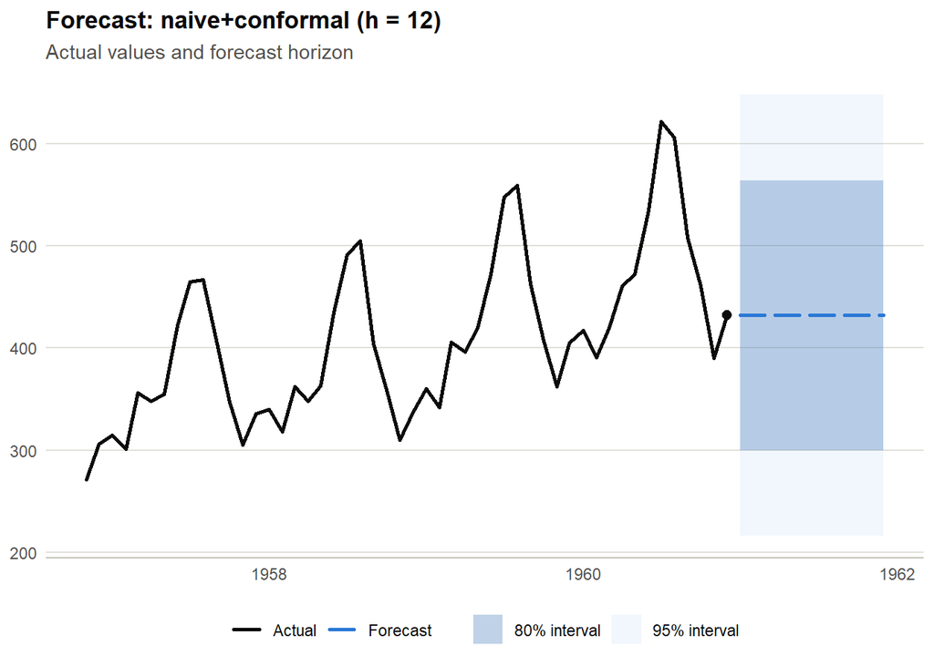

```r
plot(conformal_fct)
```

# Ensemble Models

Combine multiple models with averaging or weighted combinations.

```r
ap <- milt_series(AirPassengers)

m1 <- milt_model("auto_arima") |> milt_fit(ap)
```

```
## Fitting <MiltAutoArima> model…
## Done in 5.95s.
```

```r
m2 <- milt_model("ets")        |> milt_fit(ap)
```

```
## Fitting <MiltEts> model…
## Done in 1.42s.
```

```r
m3 <- milt_model("naive")      |> milt_fit(ap)
```

```
## Fitting <MiltNaive> model…
## Done in 0s.
```

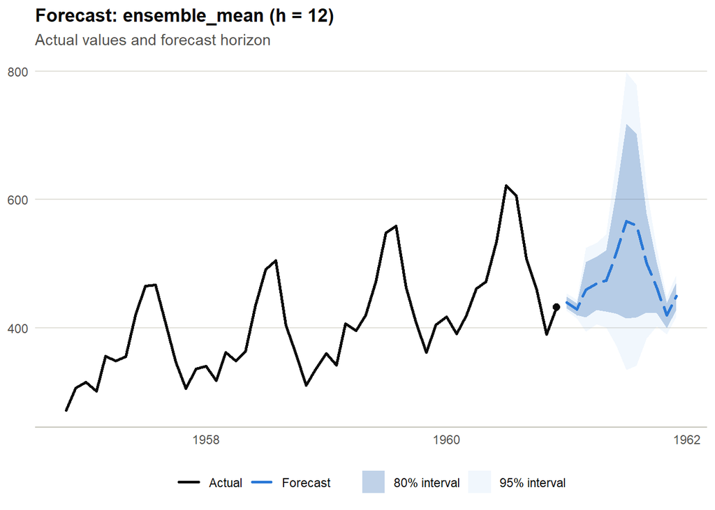

```r
ens <- milt_ensemble(
  list(arima = m1, ets = m2, naive = m3),
  weights = c(0.5, 0.4, 0.1)
)

ens_fct <- milt_forecast(ens, horizon = 12)
plot(ens_fct)
```

# Feature Engineering with Pipelines

The pipeline system lets you compose data transformations into a reusable, fittable object. Pipelines fit on training data and can be applied to new data — preventing data leakage.

## Building a Pipeline

A pipeline always needs a model attached as its final step. Use `milt_pipe_model()` to attach one.

```r
ap <- milt_series(AirPassengers)

pipe <- milt_pipeline() |>
  milt_pipe_step_lag(lags = 1:12) |>
  milt_pipe_step_rolling(windows = c(3, 6, 12), fns = c("mean", "sd")) |>
  milt_pipe_step_fourier(K = 3) |>
  milt_pipe_step_calendar() |>
  milt_pipe_step_scale() |>
  milt_pipe_model(milt_model("naive"))

print(pipe)
```

```
## # A MiltPipeline [unfitted]# Steps : 51. lag2. rolling3. fourier4. calendar5. scale# Model : MiltNaive
```

## Fitting and Transforming

```r
spl         <- milt_split(ap, ratio = 0.8)
fitted_pipe <- milt_pipeline_fit(pipe, spl$train)
```

```
## Fitting pipeline (5 step(s))…
## Fitting <MiltNaive> model…
## Done in 0s.
## Pipeline fitted.
```

```r
# Forecast using the fitted pipeline
pipe_fct <- milt_pipeline_forecast(fitted_pipe, horizon = 12)
print(pipe_fct)
```

```
## # A MiltForecast <naive>: horizon = 12# Forecast from: 1958-07-01# Intervals    : 80, 95%#
## # A tibble: 6 × 7
##   time       .model .mean .lower_80 .upper_80 .lower_95 .upper_95
##   <date>     <chr>  <dbl>     <dbl>     <dbl>     <dbl>     <dbl>
## 1 1958-08-01 naive   2.73      2.27      3.18      2.03      3.43
## 2 1958-09-01 naive   2.73      2.08      3.37      1.74      3.72
## 3 1958-10-01 naive   2.73      1.94      3.52      1.52      3.94
## 4 1958-11-01 naive   2.73      1.82      3.64      1.33      4.12
## 5 1958-12-01 naive   2.73      1.71      3.75      1.17      4.29
## 6 1959-01-01 naive   2.73      1.61      3.85      1.02      4.44
## # … with 6 more rows
```

Sometimes you only want the engineered *features* — not a forecast. `milt_pipeline_transform()` applies a fitted pipeline’s transform steps (everything except the model) to any series and hands back the resulting feature table, useful for feeding milt’s feature engineering into an external modelling workflow:

```r
transformed_test <- milt_pipeline_transform(fitted_pipe, spl$test)
head(transformed_test)
```

```
## # A MiltSeries: 6 x 1 [monthly]
## # Time range : 1960 Jul — 1960 Dec
## # Components : value
## # Gaps       : none
## # A tibble: 6 × 31
##   time       value .lag_1 .lag_2 .lag_3 .lag_4 .lag_5 .lag_6 .lag_7 .lag_8
##   <date>     <dbl>  <dbl>  <dbl>  <dbl>  <dbl>  <dbl>  <dbl>  <dbl>  <dbl>
## 1 1960-07-01  4.32    535    472    461    419    391    417    405    362
## 2 1960-08-01  4.13    622    535    472    461    419    391    417    405
## 3 1960-09-01  2.94    606    622    535    472    461    419    391    417
## 4 1960-10-01  2.36    508    606    622    535    472    461    419    391
## 5 1960-11-01  1.50    461    508    606    622    535    472    461    419
## 6 1960-12-01  2.01    390    461    508    606    622    535    472    461
## # ℹ 21 more variables: .lag_9 <dbl>, .lag_10 <dbl>, .lag_11 <dbl>,
## #   .lag_12 <dbl>, .rolling_mean_3 <dbl>, .rolling_sd_3 <dbl>,
## #   .rolling_mean_6 <dbl>, .rolling_sd_6 <dbl>, .rolling_mean_12 <dbl>,
## #   .rolling_sd_12 <dbl>, .fourier_sin_1 <dbl>, .fourier_cos_1 <dbl>,
## #   .fourier_sin_2 <dbl>, .fourier_cos_2 <dbl>, .fourier_sin_3 <dbl>,
## #   .fourier_cos_3 <dbl>, .day_of_week <int>, .month <int>, .quarter <int>,
## #   .year <int>, .week <int>
```

## Pipeline + Model

Attach a model as the final step of the pipeline:

```r
full_pipe <- milt_pipeline() |>
  milt_pipe_step_lag(lags = 1:12) |>
  milt_pipe_step_rolling(windows = c(3, 6), fns = "mean") |>
  milt_pipe_step_scale() |>
  milt_pipe_model(milt_model("xgboost"))

pipe_fit <- milt_pipeline_fit(full_pipe, spl$train)
pipe_fct <- milt_pipeline_forecast(pipe_fit, horizon = 12)
plot(pipe_fct)
```

# Individual Feature Steps

The `milt_step_*` functions work directly on a `MiltSeries` without a full pipeline.

```r
ap <- milt_series(AirPassengers)

# Scale the series (z-score normalisation)
scaled <- milt_step_scale(ap)
print(scaled)
```

```
## $series
## # A MiltSeries: 144 x 1 [monthly]
## # Time range : 1949 Jan — 1960 Dec
## # Components : value
## # Gaps       : none
## # A tibble: 6 × 2
##   time       value
##   <date>     <dbl>
## 1 1949-01-01 -1.40
## 2 1949-02-01 -1.35
## 3 1949-03-01 -1.24
## 4 1949-04-01 -1.26
## 5 1949-05-01 -1.33
## 6 1949-06-01 -1.21
## # … with 138 more rows
## $step
## # MiltScaleStep [zscore]
## # Columns: value
```

```r
# Add lag features (returns tibble)
lag_df <- milt_step_lag(ap, lags = c(1, 3, 12))
head(lag_df)
```

```
## # A MiltSeries: 6 x 1 [monthly]
## # Time range : 1950 Jan — 1950 Jun
## # Components : value
## # Gaps       : none
## # A tibble: 6 × 5
##   time       value .lag_1 .lag_3 .lag_12
##   <date>     <dbl>  <dbl>  <dbl>   <dbl>
## 1 1950-01-01   115    118    119     112
## 2 1950-02-01   126    115    104     118
## 3 1950-03-01   141    126    118     132
## 4 1950-04-01   135    141    115     129
## 5 1950-05-01   125    135    126     121
## 6 1950-06-01   149    125    141     135
```

```r
# Rolling statistics
roll_df <- milt_step_rolling(ap, windows = 6, fns = "mean")
head(roll_df)
```

```
## # A MiltSeries: 6 x 1 [monthly]
## # Time range : 1949 Jun — 1949 Nov
## # Components : value
## # Gaps       : none
## # A tibble: 6 × 3
##   time       value .rolling_mean_6
##   <date>     <dbl>           <dbl>
## 1 1949-06-01   135            124.
## 2 1949-07-01   148            130.
## 3 1949-08-01   148            136.
## 4 1949-09-01   136            136.
## 5 1949-10-01   119            134.
## 6 1949-11-01   104            132.
```

```r
# Fourier terms for seasonality
fourier_df <- milt_step_fourier(ap, K = 2)
head(fourier_df)
```

```
## # A MiltSeries: 6 x 1 [monthly]
## # Time range : 1949 Jan — 1949 Jun
## # Components : value
## # Gaps       : none
## # A tibble: 6 × 6
##   time       value .fourier_sin_1 .fourier_cos_1 .fourier_sin_2 .fourier_cos_2
##   <date>     <dbl>          <dbl>          <dbl>          <dbl>          <dbl>
## 1 1949-01-01   112       5   e- 1       8.66e- 1       8.66e- 1          0.5
## 2 1949-02-01   118       8.66e- 1       5   e- 1       8.66e- 1         -0.5
## 3 1949-03-01   132       1   e+ 0       6.12e-17       1.22e-16         -1
## 4 1949-04-01   129       8.66e- 1      -5   e- 1      -8.66e- 1         -0.500
## 5 1949-05-01   121       5   e- 1      -8.66e- 1      -8.66e- 1          0.5
## 6 1949-06-01   135       1.22e-16      -1   e+ 0      -2.45e-16          1
```

```r
# Calendar features (month, quarter, weekday, …)
cal_df <- milt_step_calendar(ap)
head(cal_df)
```

```
## # A MiltSeries: 6 x 1 [monthly]
## # Time range : 1949 Jan — 1949 Jun
## # Components : value
## # Gaps       : none
## # A tibble: 6 × 8
##   time       value .year .month .quarter .week .day_of_week .is_weekend
##   <date>     <dbl> <int>  <int>    <int> <int>        <int>       <int>
## 1 1949-01-01   112  1949      1        1    53            6           1
## 2 1949-02-01   118  1949      2        1     5            2           0
## 3 1949-03-01   132  1949      3        1     9            2           0
## 4 1949-04-01   129  1949      4        2    13            5           0
## 5 1949-05-01   121  1949      5        2    17            7           1
## 6 1949-06-01   135  1949      6        2    22            3           0
```

```r
# Box-Cox power transform (auto-estimated lambda) — stabilises variance
bc_out <- milt_step_boxcox(ap)
bc_out$step$lambda()
```

```
## [1] 0.1480227
```

```r
# Invert back to the original scale
restored <- bc_out$step$inverse_transform(bc_out$series)
all.equal(as.numeric(restored$values()), as.numeric(ap$values()))
```

```
## [1] TRUE
```

```r
# Sequential lagged differencing: remove a trend, then yearly seasonality
diff_out <- milt_step_diff(ap, lags = c(1, 12))
diff_out$series$n_timesteps()   # 144 - 13 = 131
```

```
## [1] 131
```

```r
# Fully invertible, including reconstructing the dropped leading timestamps
undiffed <- diff_out$step$inverse_transform(diff_out$series)
undiffed$n_timesteps()          # back to 144
```

```
## [1] 144
```

```r
# Generic elementwise transform, with an optional invertible pair
map_out <- milt_step_map(ap, fn = log1p, inverse_fn = expm1)
map_out$series
```

```
## # A MiltSeries: 144 x 1 [monthly]
## # Time range : 1949 Jan — 1960 Dec
## # Components : value
## # Gaps       : none
## # A tibble: 6 × 2
##   time       value
##   <date>     <dbl>
## 1 1949-01-01  4.73
## 2 1949-02-01  4.78
## 3 1949-03-01  4.89
## 4 1949-04-01  4.87
## 5 1949-05-01  4.80
## 6 1949-06-01  4.91
## # … with 138 more rows
```

# Anomaly Detection

## The Detector Interface

Like models, detectors follow a two-step interface:

```
milt_detector("<method>")  →  milt_detect(<series>)
```

## Statistical Methods

```r
ap <- milt_series(AirPassengers)

# IQR-based detection (classical box-plot rule)
iqr_result <- milt_detector("iqr") |> milt_detect(ap)
print(iqr_result)
```

```
## # MiltAnomalies [iqr]
## # Series    : 144 observations  1949-01-01 — 1960-12-01
## # Anomalies : 0 / 144 (0%)
```

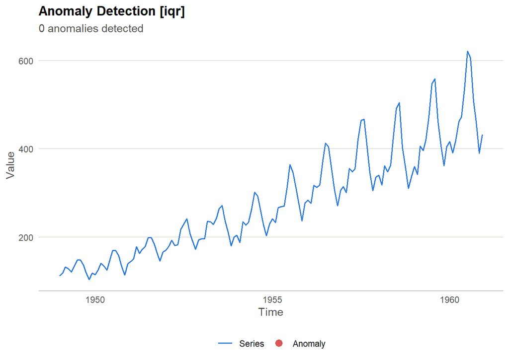

```r
plot(iqr_result)
```

```r
# STL decomposition — flags residuals outside ±3 SD
stl_result <- milt_detector("stl") |> milt_detect(ap)
print(stl_result)
```

```
## # MiltAnomalies [stl]
## # Series    : 144 observations  1949-01-01 — 1960-12-01
## # Anomalies : 6 / 144 (4.2%)# Anomalous times:
## # A tibble: 6 × 3
##   time       value .anomaly_score
##   <date>     <dbl>          <dbl>
## 1 1958-07-01   491           3.17
## 2 1958-08-01   505           3.36
## 3 1959-07-01   548           3.54
## 4 1959-08-01   559           3.53
## 5 1960-07-01   622           4.39
## 6 1960-08-01   606           3.44
```

```r
# Grubbs test (univariate extreme value)
grubbs_result <- milt_detector("grubbs") |> milt_detect(ap)
print(grubbs_result)
```

```r
# Generalised ESD test (multiple outliers)
gesd_result <- milt_detector("gesd") |> milt_detect(ap)
print(gesd_result)
```

```
## # MiltAnomalies [gesd]
## # Series    : 144 observations  1949-01-01 — 1960-12-01
## # Anomalies : 0 / 144 (0%)
```

## Machine Learning Methods

```r
# Local Outlier Factor
lof_result <- milt_detector("lof") |> milt_detect(ap)
print(lof_result)
```

```r
# Isolation Forest
iforest_result <- milt_detector("iforest") |> milt_detect(ap)
print(iforest_result)
```

```r
# Autoencoder (deep learning)
ae_result <- milt_detector("autoencoder") |> milt_detect(ap)
print(ae_result)
```

## Ensemble Detection

Combine multiple detectors — a point is anomalous only if a majority vote says so.

```r
ens_result <- milt_detector("ensemble",
  detectors = list(
    milt_detector("iqr"),
    milt_detector("gesd")
  )
) |> milt_detect(ap)
print(ens_result)
```

```
## # MiltAnomalies [ensemble]
## # Series    : 144 observations  1949-01-01 — 1960-12-01
## # Anomalies : 0 / 144 (0%)
```

## MiltAnomalies Result Object

```r
result <- milt_detector("iqr") |> milt_detect(ap)

# Convert to tibble
tibble::as_tibble(result) |> dplyr::filter(is_anomaly) |> head()
```

```
## # A tibble: 0 × 6
## # ℹ 6 variables: time <date>, value <dbl>, .is_anomaly <lgl>,
## #   .anomaly_score <dbl>, is_anomaly <lgl>, anomaly_score <dbl>
```

## Anomaly Detection via Forecast Residuals

The detectors above look for outliers directly in the raw series. `milt_anomaly_model()` takes a different, complementary approach — the same one Darts calls a `ForecastingAnomalyModel`: wrap **any** already-registered forecaster, fit it, score its residuals, and flag the points whose residual score crosses a threshold. A point the series *looks* normal at but that the model badly mispredicted is exactly the kind of anomaly this catches and a raw-value detector would miss.

`milt_anomaly_score()` supplies the scoring function — `"norm"` (absolute residual), `"difference"` (signed residual), or `"nll_gaussian"` (negative log-likelihood under a Gaussian fit to the residual distribution, penalising extreme residuals more sharply) — and the detector thresholds those scores either by `"quantile"` or explicit `"threshold"` bounds.

```r
am    <- milt_anomaly_model(milt_model("naive"), scorer = "norm", detector = "quantile", quantile = 0.95) |>
  milt_fit(ap)
```

```
## Fitting <MiltAnomalyModel> model…
## Done in 0s.
```

```r
anoms <- milt_detect_anomalies(am)

print(anoms)
```

```
## # MiltAnomalies [naive+norm]
## # Series    : 144 observations  1949-01-01 — 1960-12-01
## # Anomalies : 8 / 144 (5.6%)# Anomalous times:
## # A tibble: 8 × 3
##   time       value .anomaly_score
##   <date>     <dbl>          <dbl>
## 1 1957-06-01   422             67
## 2 1958-06-01   435             72
## 3 1958-09-01   404            101
## 4 1959-07-01   548             76
## 5 1959-09-01   463             96
## 6 1960-07-01   622             87
## 7 1960-09-01   508             98
## 8 1960-11-01   390             71
```

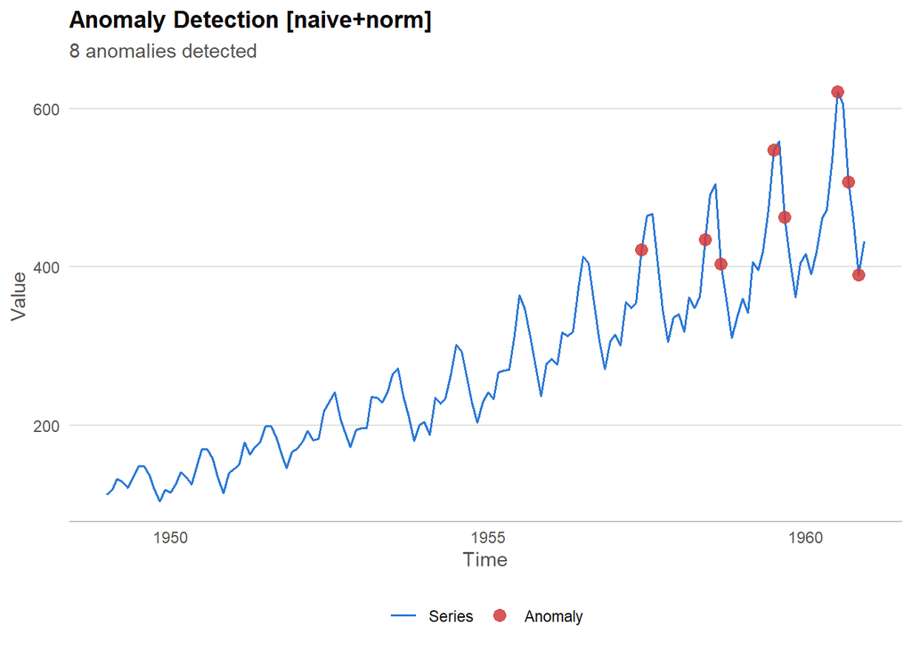

```r
plot(anoms)
```

Fitting a `MiltAnomalyModel` clones the wrapped model internally, so the original `milt_model("naive")` object you passed in is never mutated. The wrapped model stays fully accessible — `am$model()` returns the fitted forecaster itself, and `am$scores()` returns the raw per-point anomaly scores that were thresholded — and the result is a standard `MiltAnomalies` object, so every `plot()`/`print()`/`as_tibble()` method you already know keeps working.

# Change-Point Detection

```r
ap <- milt_series(AirPassengers)

cp_result <- milt_changepoints(ap, method = "pelt")
print(cp_result)
plot(cp_result)
```

# Multi-Series Analysis

## Creating a Multi-Series Object

```r
# Simulate three store sales series
set.seed(42)
sales_df <- data.frame(
  date  = rep(seq(as.Date("2019-01-01"), by = "month", length.out = 48), 3),
  store = rep(c("A", "B", "C"), each = 48),
  sales = c(
    100 + cumsum(rnorm(48, 1, 3)),
    200 + cumsum(rnorm(48, 2, 5)),
    150 + cumsum(rnorm(48, 0.5, 2))
  )
)

ms <- milt_series(sales_df,
  time_col  = "date",
  value_col = "sales",
  group_col = "store",
  frequency = 12
)

print(ms)
```

```
## # A MiltSeries: 48 x 1 [12] | 3 series
## # Time range : 2019-01-01 — 2022-12-01
## # Components : sales
## # Groups     : store (3 series)
## # Gaps       : none
## # A tibble: 6 × 3
##   date       store sales
##   <date>     <chr> <dbl>
## 1 2019-01-01 A      105.
## 2 2019-02-01 A      104.
## 3 2019-03-01 A      107.
## 4 2019-04-01 A      109.
## 5 2019-05-01 A      112.
## 6 2019-06-01 A      112.
## # … with 138 more rows
```

## Fitting Models Across All Groups

```r
# Fit ETS to every store independently
ms_fit <- milt_model("ets") |> milt_fit(ms)
```

```
## Fitting <MiltEts> model…
## Done in 1.64s.
```

```r
ms_fct <- milt_forecast(ms_fit, horizon = 12)
print(ms_fct)
```

```
## # A MiltForecast <ets>: horizon = 12# Forecast from: 2022-12-01# Intervals    : 80, 95%#
## # A tibble: 6 × 7
##   time       .model .mean .lower_80 .upper_80 .lower_95 .upper_95
##   <date>     <chr>  <dbl>     <dbl>     <dbl>     <dbl>     <dbl>
## 1 2022-12-31 ets     156.      144.      169.      138.      175.
## 2 2023-01-30 ets     156.      139.      174.      130.      183.
## 3 2023-03-01 ets     156.      135.      178.      124.      189.
## 4 2023-03-31 ets     156.      132.      181.      119.      194.
## 5 2023-04-30 ets     156.      129.      184.      114.      198.
## 6 2023-05-30 ets     156.      126.      187.      110.      203.
## # … with 6 more rows
```

## Global Models — One Shared Model Across All Groups

`milt_local_model()` (above) fits one **independent** model per group. `milt_global_model()` takes the opposite approach: it trains a single **shared** model (`"knn"` or `"xgboost"`) on every group’s data pooled together, one-hot encoding group identity and appending any static covariates as constant-per-group feature columns — the same idea as Darts training one model across a `Sequence[TimeSeries]`.

Global models are worth reaching for when groups are too short individually to train a good local model on their own, but collectively share enough structure that pooling helps — the shared model can borrow statistical strength across stores/sensors/customers.

```r
gm <- milt_global_model("knn", lags = 1:6, k = 3L) |> milt_fit(ms)
```

```
## Fitting <MiltGlobalModel> model…
## Done in 0.02s.
```

```r
# forecast() targets one group at a time
gm$forecast(horizon = 6, group = "A")
```

```
## # A MiltForecast <global_knn [A]>: horizon = 6# Forecast from: 2022-12-01# Intervals    : 80, 95%#
## # A tibble: 6 × 7
##   time       .model         .mean .lower_80 .upper_80 .lower_95 .upper_95
##   <date>     <chr>          <dbl>     <dbl>     <dbl>     <dbl>     <dbl>
## 1 2022-12-31 global_knn [A]  140.      137.      143.      135.      145.
## 2 2023-01-30 global_knn [A]  138.      135.      141.      133.      143.
## 3 2023-03-01 global_knn [A]  133.      130.      137.      129.      138.
## 4 2023-03-31 global_knn [A]  134.      131.      137.      129.      139.
## 5 2023-04-30 global_knn [A]  139.      136.      142.      134.      144.
## 6 2023-05-30 global_knn [A]  138.      135.      142.      134.      143.
```

```r
# forecast_all() runs every group through the one shared model at once
all_fcts <- gm$forecast_all(horizon = 6)
all_fcts[["B"]]
```

```
## # A MiltForecast <global_knn [B]>: horizon = 6# Forecast from: 2022-12-01# Intervals    : 80, 95%#
## # A tibble: 6 × 7
##   time       .model         .mean .lower_80 .upper_80 .lower_95 .upper_95
##   <date>     <chr>          <dbl>     <dbl>     <dbl>     <dbl>     <dbl>
## 1 2022-12-31 global_knn [B]  334.      331.      337.      329.      339.
## 2 2023-01-30 global_knn [B]  334.      331.      337.      329.      339.
## 3 2023-03-01 global_knn [B]  334.      331.      337.      329.      339.
## 4 2023-03-31 global_knn [B]  334.      331.      337.      329.      339.
## 5 2023-04-30 global_knn [B]  334.      331.      337.      329.      339.
## 6 2023-05-30 global_knn [B]  334.      331.      337.      329.      339.
```

Despite sharing one set of learned weights, each group still gets a genuinely different forecast — the group indicator (and any static covariates) let the shared model tell the groups apart.

# Hierarchical Reconciliation

When your series form a hierarchy (e.g., country → region → store), forecasts at lower levels should sum to the forecast at the higher level. `milt_reconcile()` enforces this.

```r
set.seed(42)
# Three individual series: total, region_A, region_B
make_hier <- function(n, mean_drift) {
  milt_series(300 + cumsum(rnorm(n, mean_drift, 3)),
              frequency = 12, start = c(2019, 1))
}

s_total    <- make_hier(48, 3)
s_region_a <- make_hier(48, 1)
s_region_b <- make_hier(48, 2)

# Fit ETS independently on each series
fct_total    <- milt_model("ets") |> milt_fit(s_total)    |> milt_forecast(horizon = 12)
```

```
## Fitting <MiltEts> model…
## Done in 1.16s.
```

```r
fct_region_a <- milt_model("ets") |> milt_fit(s_region_a) |> milt_forecast(horizon = 12)
```

```
## Fitting <MiltEts> model…
## Done in 1s.
```

```r
fct_region_b <- milt_model("ets") |> milt_fit(s_region_b) |> milt_forecast(horizon = 12)
```

```
## Fitting <MiltEts> model…
## Done in 0.92s.
```

```r
# Summation matrix S: rows = [total, region_A, region_B], cols = [region_A, region_B]
S <- matrix(
  c(1, 1,   # total  = region_A + region_B
    1, 0,   # region_A
    0, 1),  # region_B
  nrow = 3, ncol = 2, byrow = TRUE
)

# Reconcile — forecasts is a named list of MiltForecast objects
reconciled <- milt_reconcile(
  forecasts = list(total = fct_total, region_A = fct_region_a, region_B = fct_region_b),
  S         = S,
  method    = "ols"
)
print(reconciled)
```

```
## # MiltReconciliation [ols]
## # Series: total, region_A, region_B
```

```r
tibble::as_tibble(reconciled)
```

```
## # A tibble: 36 × 3
##    series     h .mean
##    <chr>  <int> <dbl>
##  1 total      1  541.
##  2 total      2  544.
##  3 total      3  547.
##  4 total      4  550.
##  5 total      5  552.
##  6 total      6  555.
##  7 total      7  558.
##  8 total      8  561.
##  9 total      9  564.
## 10 total     10  566.
## # ℹ 26 more rows
```

# Time Series Classification

Classify time series into predefined categories. Useful for product type detection, fault classification, customer segmentation, and more.

```r
# Build labelled training data
set.seed(1)
make_series <- function(n, trend, noise) {
  milt_series(cumsum(rnorm(n, trend, noise)),
    frequency = 1, start = c(2020, 1))
}

# Three classes: trending up, flat, trending down
train_series <- list(
  s1 = make_series(50,  0.5, 1),
  s2 = make_series(50,  0.0, 1),
  s3 = make_series(50, -0.5, 1),
  s4 = make_series(50,  0.6, 1),
  s5 = make_series(50, -0.4, 1)
)

labels <- c("up", "flat", "down", "up", "down")

# Fit classifier
clf <- milt_classifier("random_forest") |>
  milt_classify_fit(train_series, labels)

# Predict on new series
new_series <- list(
  t1 = make_series(50,  0.4, 1),
  t2 = make_series(50, -0.3, 1)
)

predictions <- milt_classify_predict(clf, new_series)
print(predictions)
```

# Time Series Clustering

Group similar time series together without labels.

```r
# Simulate 9 series from 3 underlying patterns
set.seed(42)
series_list <- lapply(1:9, function(i) {
  group   <- (i - 1) %% 3
  trend   <- c(0.3, 0, -0.3)[group + 1]
  vals    <- cumsum(rnorm(60, trend, 1))
  milt_series(vals, frequency = 12, start = c(2018, 1))
})

cl_result <- milt_cluster(series_list, k = 3, method = "dtw")
print(cl_result)
```

# Explainability

`milt_explain()` uses SHAP-style feature importance to show which lag/feature values drove each forecast.

```r
ap <- milt_series(AirPassengers)

xgb_model <- milt_model("xgboost", lags = 1:12) |> milt_fit(ap)
explanation <- milt_explain(xgb_model, ap)

print(explanation)
plot(explanation)
```

# Causal Impact Analysis

Measure the effect of an intervention (e.g., a marketing campaign, product launch, policy change) by building a counterfactual forecast of what *would have* happened without it.

```r
set.seed(1)
n        <- 100
pre_n    <- 70
baseline <- cumsum(rnorm(n, 0.5, 1)) + 100

# Add a treatment effect from observation 71 onwards
treatment                       <- baseline
treatment[(pre_n + 1):n] <- treatment[(pre_n + 1):n] + 15

dates  <- seq(as.Date("2016-01-01"), by = "week", length.out = n)
series <- milt_series(treatment, frequency = 52, start = c(2016, 1))

ci_result <- milt_causal_impact(
  series,
  event_time = dates[pre_n + 1]
)

print(ci_result)
plot(ci_result)
```

# Saving and Loading Models

Trained models can be serialised to disk and reloaded in a fresh session.

```r
ap    <- milt_series(AirPassengers)
model <- milt_model("ets") |> milt_fit(ap)
```

```
## Fitting <MiltEts> model…
## Done in 1.61s.
```

```r
# Save to a file
tmp <- tempfile(fileext = ".milt")
milt_save(model, path = tmp)
```

```
## Saved to
## 'C:\Users\GIDEON~1\AppData\Local\Temp\RtmpGm6u1l\filecb4055b84a0e.milt'.
```

```r
# Load from file
loaded <- milt_load(tmp)
fct    <- milt_forecast(loaded, horizon = 12)
print(fct)
```

```
## # A MiltForecast <ets>: horizon = 12# Forecast from: 1960-12-01# Intervals    : 80, 95%#
## # A tibble: 6 × 7
##   time       .model .mean .lower_80 .upper_80 .lower_95 .upper_95
##   <date>     <chr>  <dbl>     <dbl>     <dbl>     <dbl>     <dbl>
## 1 1961-01-01 ets     442.      420.      464.      408.      476.
## 2 1961-02-01 ets     434.      407.      461.      393.      475.
## 3 1961-03-01 ets     497.      461.      533.      442.      552.
## 4 1961-04-01 ets     483.      444.      523.      423.      544.
## 5 1961-05-01 ets     484.      440.      528.      417.      551.
## 6 1961-06-01 ets     551.      496.      606.      467.      635.
## # … with 6 more rows
```

```r
# Clean up
file.remove(tmp)
```

```
## [1] TRUE
```

# Model Registry

milt has a global model registry. You can inspect it and register your own custom model backends.

```r
# Inspect all registered models
models_tbl <- list_milt_models()
print(models_tbl)
```

```
## # A tibble: 31 × 6
##    name        description    multivariate probabilistic covariates multi_series
##    <chr>       <chr>          <lgl>        <lgl>         <lgl>      <lgl>
##  1 snaive      "Seasonal Nai… FALSE        TRUE          FALSE      FALSE
##  2 knn         "K-Nearest Ne… FALSE        TRUE          FALSE      FALSE
##  3 ets         "Exponential … FALSE        TRUE          FALSE      FALSE
##  4 nbeats      ""             FALSE        FALSE         FALSE      FALSE
##  5 auto_arima  "Automatic AR… FALSE        TRUE          TRUE       FALSE
##  6 svm         "Support Vect… FALSE        TRUE          FALSE      FALSE
##  7 stl         "STL decompos… FALSE        TRUE          FALSE      FALSE
##  8 elastic_net ""             FALSE        FALSE         FALSE      FALSE
##  9 dlinear     ""             FALSE        FALSE         FALSE      FALSE
## 10 deepar      ""             FALSE        FALSE         FALSE      FALSE
## # ℹ 21 more rows
```

Two lower-level helpers back `list_milt_models()` and `milt_model()` — useful when you’re writing code that needs to check the registry itself, e.g. inside a package extending milt with new backends:

```r
is_registered_model("naive")       # TRUE
```

```
## [1] TRUE
```

```r
is_registered_model("not_a_model") # FALSE
```

```
## [1] FALSE
```

```r
get_milt_model_class("naive")      # the MiltNaive R6 generator
```

```
## <MiltNaive> object generator
##   Inherits from: <MiltModelBase>
##   Public:
##     initialize: function (...)
##     fit: function (series, ...)
##     forecast: function (horizon, level = c(80, 95), num_samples = NULL, future_covariates = NULL,
##     predict: function (series = NULL, ...)
##     residuals: function (...)
##     clone: function (deep = FALSE)
##   Parent env: <environment: namespace:milt>
##   Locked objects: TRUE
##   Locked class: FALSE
##   Portable: TRUE
```

## Registering a Custom Model

You can register any R6 class that follows the `MiltModelBase` interface:

```r
# Minimal custom model skeleton
MyCustomModel <- R6::R6Class(
  classname = "MyCustomModel",
  inherit   = MiltModelBase,
  public = list(
    fit = function(series) {
      # ... fit logic ...
      private$.is_fitted <- TRUE
      invisible(self)
    },
    forecast = function(horizon, ...) {
      # ... forecast logic ...
    },
    predict = function(series = NULL, ...) {
      # ... in-sample prediction ...
    },
    residuals = function(...) {
      # ... residuals ...
    }
  )
)

# Register it
register_milt_model(
  name        = "my_model",
  class       = MyCustomModel,
  description = "My custom model"
)

# Use it just like any built-in model
milt_model("my_model") |> milt_fit(ap) |> milt_forecast(horizon = 12)
```

# Deployment

## Generating a Report

`milt_report()` renders an HTML / PDF report from a fitted forecast.

```r
# Requires pandoc and rmarkdown
ap    <- milt_series(AirPassengers)
model <- milt_model("ets") |> milt_fit(ap)

milt_report(
  series      = ap,
  models      = list(ets = model),
  horizon     = 24L,
  output_format = "html",
  output_file   = "my_forecast_report.html"
)
```

## Interactive Dashboard

`milt_dashboard()` launches a Shiny dashboard to explore forecasts interactively.

```r
# Requires shiny
milt_dashboard(
  model  = model,
  series = ap
)
```

## REST API with Plumber

`milt_serve()` wraps a trained model as a REST API using the `plumber` package.

```r
# Requires plumber
api <- milt_serve(model, port = 8080)

# Then call your model:
# POST http://localhost:8080/predict  {"horizon": 12}
```

# Deep Dive: The Architecture

Understanding how milt is structured helps when extending it.

## 4-Layer Architecture

```
┌──────────────────────────────────────────────────┐
│  Layer 1: User API                               │
│  milt_model(), milt_fit(), milt_forecast(), …    │
│  S3 generics: print(), plot(), summary()         │
├──────────────────────────────────────────────────┤
│  Layer 2: Core Engine                            │
│  MiltSeriesR6, MiltForecastR6, ModelRegistry     │
│  MiltAnomaliesR6, MiltBacktestR6, …              │
├──────────────────────────────────────────────────┤
│  Layer 3: Model Backends                         │
│  backend-arima.R, backend-ets.R, backend-xgb.R  │
│  backend-nbeats.R, detect-iqr.R, …              │
├──────────────────────────────────────────────────┤
│  Layer 4: Data Layer                             │
│  tsibble, arrow, data.table, tibble              │
└──────────────────────────────────────────────────┘
```

## Adding a New Model Backend

1. Create `R/backend-mymodel.R`
2. Define an R6 class inheriting `MiltModelBase`
3. Implement `fit()`, `forecast()`, `predict()`, `residuals()`
4. Call `register_milt_model()` at package load time
5. Done — no changes needed anywhere else

## The Dependency Strategy

| Type | Packages | Behaviour |
| --- | --- | --- |
| **Imports** | `R6`, `rlang`, `cli`, `dplyr`, `tibble`, `tsibble`, … | Always available |
| **Suggests** | `forecast`, `xgboost`, `torch`, `prophet`, … | Loaded on demand via `check_installed_backend()` |

# Complete End-to-End Example

Let’s walk through a complete forecasting workflow — from raw data to deployed forecast — in one coherent example.

```r
# ── 1. Create the series ──────────────────────────────────────────────────────
ap <- milt_series(AirPassengers, frequency = 12, start = c(1949, 1))
print(ap)

# ── 2. Explore ────────────────────────────────────────────────────────────────
eda_result <- milt_eda(ap)
print(eda_result)

# ── 3. Diagnose ───────────────────────────────────────────────────────────────
milt_diagnose(ap)

# ── 4. Split ──────────────────────────────────────────────────────────────────
spl <- milt_split(ap, ratio = 0.8)

# ── 5. Detect anomalies on training data ─────────────────────────────────────
anomalies <- milt_detector("iqr") |> milt_detect(spl$train)
print(anomalies)

# ── 6. Fit and compare three models ──────────────────────────────────────────
cmp <- milt_compare(
  models = list(
    ets   = milt_model("ets"),
    arima = milt_model("auto_arima"),
    knn   = milt_model("knn", lags = 1:12)
  ),
  series  = spl$train,
  horizon = spl$test$n_timesteps()
)
print(cmp)

# ── 7. Pick best and forecast ─────────────────────────────────────────────────
best_model <- milt_model("ets") |> milt_fit(ap)
final_fct  <- milt_forecast(best_model, horizon = 24)

plot(final_fct)

# ── 8. Score on held-out test set ─────────────────────────────────────────────
test_fct <- milt_model("ets") |>
  milt_fit(spl$train) |>
  milt_forecast(spl$test$n_timesteps())

milt_accuracy(spl$test$values(), tibble::as_tibble(test_fct)$.mean)
```

# Quick Reference

## Series Functions

| Function | Purpose |
| --- | --- |
| `milt_series()` | Create a MiltSeries |
| `milt_head()` / `milt_tail()` | First / last N observations |
| `milt_window()` | Subset by date range |
| `s[i]` | Subset by integer index, logical, or date range |
| `milt_split()` | Train/test split by ratio |
| `milt_split_at()` | Train/test split by date |
| `milt_concat()` | Join two series end-to-end (by time) |
| `milt_stack()` | Combine series side by side (by component) |
| `milt_resample()` | Change frequency |
| `milt_fill_gaps()` | Interpolate missing values |
| `milt_filter()` | Smooth an observed series (moving average / Kalman / GP) |
| `+`, `-`, `*`, `/`, `^` | Arithmetic between series and/or scalars |
| `milt_add_datetime_component()` | Append a calendar attribute as a new component |
| `milt_add_holidays()` | Append a binary holiday indicator component |
| `milt_check_seasonality()` | Detect the strongest significant seasonal period |
| `milt_to_tibble()` | Convert to tibble |
| `milt_to_ts()` | Convert to base R `ts` |
| `milt_to_tsibble()` | Convert to tsibble |
| `as.data.table()` | Convert to data.table |
| `milt_write_parquet()` / `milt_read_parquet()` | Parquet I/O via `arrow` |

## Model Functions

| Function | Purpose |
| --- | --- |
| `list_milt_models()` | Show all registered models |
| `milt_model(name)` | Instantiate a model |
| `milt_fit(model, series)` | Train the model |
| `milt_forecast(model, horizon)` | Generate forecasts |
| `milt_predict(model)` | In-sample fitted values |
| `milt_residuals(model)` | Training residuals |
| `milt_backtest()` | Rolling-window backtest |
| `milt_cv()` | Time-series cross-validation |
| `milt_compare()` | Side-by-side model comparison |
| `milt_grid_search()` | Hyperparameter search via backtesting |
| `milt_conformal()` | Model-agnostic conformal intervals |
| `milt_ensemble()` | Weighted model ensemble |
| `milt_local_model()` | Fit any model independently per group |

## Model Names

| Name | Type | Package |
| --- | --- | --- |
| `"naive"` | Baseline | — |
| `"snaive"` | Baseline | — |
| `"drift"` | Baseline | — |
| `"mean"` | Baseline | — |
| `"moving_average"` | Baseline | — |
| `"auto_arima"` | Classical | forecast |
| `"ets"` | Classical | forecast |
| `"stl"` | Classical | forecast |
| `"theta"` | Classical | forecast |
| `"tbats"` | Classical | forecast |
| `"croston"` | Classical | forecast |
| `"prophet"` | Classical | prophet |
| `"xgboost"` | ML | xgboost |
| `"lightgbm"` | ML | lightgbm |
| `"random_forest"` | ML | ranger |
| `"elastic_net"` | ML | glmnet |
| `"svm"` | ML | e1071 |
| `"knn"` | ML | — |
| `"nbeats"` | Deep Learning | torch |
| `"nhits"` | Deep Learning | torch |
| `"tcn"` | Deep Learning | torch |
| `"tft"` | Deep Learning | torch |
| `"patch_tst"` | Deep Learning | torch |
| `"deepar"` | Deep Learning | torch |
| `"nlinear"` | Deep Learning | torch |
| `"dlinear"` | Deep Learning | torch |
| `"tide"` | Deep Learning | torch |
| `"tsmixer"` | Deep Learning | torch |
| `"darts_rnn"` | Deep Learning | reticulate + Darts |
| `"darts_transformer"` | Deep Learning | reticulate + Darts |
| `"darts_nbeats"` | Deep Learning | reticulate + Darts |

## Filtering Models

| Name | Method |
| --- | --- |
| `"moving_average"` | Rolling-mean smoother |
| `"kalman"` | State-space smoothing via `stats::StructTS()` |
| `"gp"` | Gaussian Process smoother (RBF kernel) |

## Feature / Transform Steps

| Function | Purpose |
| --- | --- |
| `milt_step_lag()` | Lag features |
| `milt_step_rolling()` | Rolling-window statistics |
| `milt_step_fourier()` | Fourier seasonal terms |
| `milt_step_calendar()` | Calendar dummy features |
| `milt_step_scale()` / `milt_step_unscale()` | Invertible normalisation (z-score/minmax/robust) |
| `milt_step_boxcox()` / `milt_step_unboxcox()` | Invertible Box-Cox power transform |
| `milt_step_diff()` / `milt_step_undiff()` | Invertible sequential lagged differencing |
| `milt_step_map()` | Generic (optionally time-aware, invertible) elementwise transform |

## Anomaly Detectors

| Name | Method |
| --- | --- |
| `"iqr"` | IQR box-plot rule |
| `"stl"` | STL decomposition residuals |
| `"grubbs"` | Grubbs extreme-value test |
| `"gesd"` | Generalised ESD test |
| `"lof"` | Local Outlier Factor |
| `"iforest"` | Isolation Forest |
| `"autoencoder"` | Deep learning autoencoder |
| `"ensemble"` | Majority-vote combination |

## Metrics

| Function | Description |
| --- | --- |
| `milt_accuracy()` | Multiple metrics at once |
| `milt_mae()` | Mean Absolute Error |
| `milt_mse()` | Mean Squared Error |
| `milt_rmse()` | Root Mean Squared Error |
| `milt_mape()` | Mean Absolute % Error |
| `milt_smape()` | Symmetric MAPE |
| `milt_wmape()` | Weighted MAPE (robust to near-zero actuals) |
| `milt_ope()` | Overall Percentage Error (of the totals) |
| `milt_coefficient_of_variation()` | RMSE as a fraction of the mean |
| `milt_marre()` | Mean Absolute Ranged Relative Error |
| `milt_rmsle()` | Root Mean Squared Log Error |
| `milt_mase()` | Mean Abs Scaled Error |
| `milt_rmsse()` | Root Mean Sq Scaled Error |
| `milt_mrae()` | Mean Relative Absolute Error (vs. a benchmark) |
| `milt_r_squared()` | R² |
| `milt_crps()` | Continuous Ranked Probability Score |
| `milt_coverage()` | Prediction interval coverage |
| `milt_pinball()` | Pinball / quantile loss |
| `milt_winkler()` | Winkler interval score |